# 从熵到分布：指数、幂律、正态与玻尔兹曼的统一逻辑

胡杨博士

首次发布：2026-07-12 | 最后更新：2026-08-26 16:24 EDT

本文的核心论点：**指数分布、幂律分布、正态分布、玻尔兹曼分布不是四个独立的分布，而是同一个原理（最大熵）在不同约束下的四种表现。**

$$\text{最大化 } H = -\!\int p(x)\ln
p(x)\,dx \quad \text{subject to constraints} \quad \Longrightarrow \quad
p(x) \propto e^{-\lambda\, f(x)}$$

把四个 $f(x)$ 代进这一个式子，四个分布就依次掉出来：

| 分布 | 约束的量 $f(x)$ | 解析形式（$e^{-\lambda f(x)}$ $\xrightarrow{\text{归一化}}$ $p(x)$） |
| --- | --- | --- |
| **指数分布** | $x$ —— 均值（$x \ge 0$） | $e^{-\lambda x} \;\to\; \lambda e^{-\lambda x}$ |
| **幂律 / Pareto** | $\ln x$ —— 几何均值（$x \ge x_{\min}$） | $e^{-\lambda \ln x} = x^{-\lambda} \;\to\; (\lambda-1)\,x_{\min}^{\lambda-1}\,x^{-\lambda}$ |
| **正态分布** | $x,\ x^2$ —— 均值与方差 | $e^{-\lambda_1 x-\lambda_2 x^2} \;\to\; \dfrac{1}{\sqrt{2\pi}\,\sigma}\,e^{-(x-\mu)^2/2\sigma^2}$ |
| **玻尔兹曼分布** | $E(x)$ —— 能量 | $e^{-\lambda E(x)} \;\to\; \dfrac{1}{Z}\,e^{-E(x)/k_BT}$ |

第二行值得盯一眼：$e^{-\lambda\ln x}$ 就是 $x^{-\lambda}$——**把约束从”$x$ 的均值”换成”$\ln x$ 的均值”，指数分布当场变成幂律**。同理第三行多加一个 $x^2$ 就配出高斯的平方项，第四行把 $\lambda$ 认成 $1/k_BT$ 就是物理学家的玻尔兹曼因子。四个分布之间没有跨越，只有 $f(x)$ 换了一次。

# 1 为什么是最大熵？

在最大化熵之前，先回答一个更根本的问题：**凭什么要最大化熵？** 有两条独立的路都通向它——物理的计数论证，和统计的无偏推断论证。

## 1.1 计数论证：熵 = 排列数的对数

做 $N$ 次观测，每次结果落入 $k$ 个类别之一。记 $n_i$ 为**类别 $i$ 出现的次数**（$i = 1, \dots, k$，满足 $n_1 + n_2 + \cdots + n_k = N$）。**宏观状态**是计数向量 $(n_1, \dots, n_k)$——只记”每类出现多少次”；**微观状态**是具体的观测序列——还记”哪一次是哪一类”。一个宏观状态对应的微观排列数是多项式系数：

$$W = \frac{N!}{n_1!\,n_2!\cdots
n_k!}$$

抛硬币是 $k=2$ 的特例：类别只有正/反，$n_1 = k_{\text{正}}$，$n_2 = N - k_{\text{正}}$，于是

$$W =
\frac{N!}{k_{\text{正}}!\,(N-k_{\text{正}})!} =
\binom{N}{k_{\text{正}}}$$

**证明 $\ln W \approx N \cdot H$**：

$$\begin{aligned}
\ln W &= \ln N! - \sum_i \ln n_i! \\[2pt]
&\approx \bigl(N\ln N - N\bigr) - \sum_i \bigl(n_i \ln n_i -
n_i\bigr)
&& \text{Stirling: } \ln n! \approx n\ln n - n \\[2pt]
&= N\ln N - \sum_i n_i \ln n_i
&& \textstyle\sum_i n_i = N \text{，两个线性项相消} \\[2pt]
&= \sum_i n_i \ln N - \sum_i n_i \ln n_i
&& \textstyle N\ln N = \bigl(\sum_i n_i\bigr)\ln N
\text{，常数 } \ln N \text{ 乘进求和} \\[2pt]
&= \sum_i n_i \bigl(\ln N - \ln n_i\bigr)
&& \text{同一求和指标，合并并提出 } n_i \\[2pt]
&= -\sum_i n_i \ln\frac{n_i}{N}
&& \textstyle\ln N - \ln n_i = -\ln\frac{n_i}{N}
\text{（对数商法则），负号提出} \\[2pt]
&= N \cdot \left(-\sum_i p_i \ln p_i\right)
&& p_i = n_i / N \\[2pt]
&= N \cdot H(p) \qquad \blacksquare
\end{aligned}$$

即 $W \approx e^{N H}$：**熵是每次观测平摊到的”排列数指数”**。两个分布的熵哪怕只差一点点，排列数就差 $e^{N\cdot\Delta H}$ 倍——$N$ 大时是天文数字。所以”熵最大的分布”不是抽象偏好，而是**压倒性地更可能出现的宏观状态**。

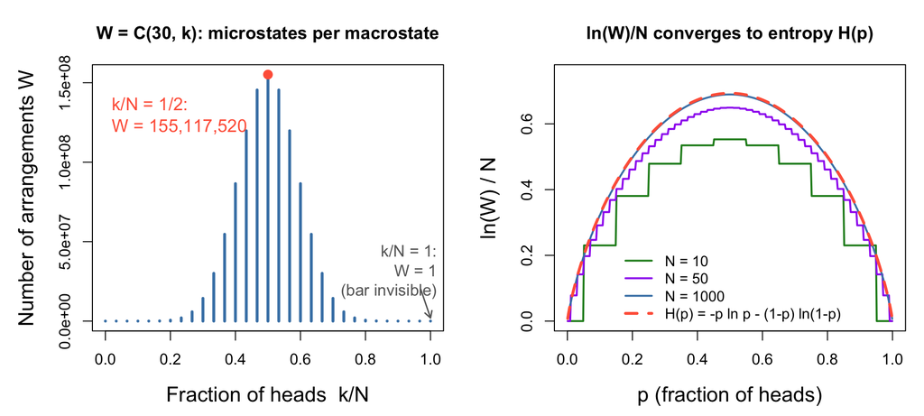

```r
## ── 计数直觉：熵大 = 微观排列数多 = 压倒性地更可能 ──────────

par(mfrow = c(1, 2), mar = c(4.6, 5.0, 3.5, 1))

# 左图：抛 30 次硬币，正面次数 k 对应的排列数 W = C(30, k)
n_flip <- 30
k <- 0:n_flip
W <- choose(n_flip, k)
plot(k / n_flip, W, type = "h", lwd = 3, col = "steelblue",
     main = paste0("W = C(", n_flip, ", k): microstates per macrostate"),
     xlab = "Fraction of heads  k/N", ylab = "Number of arrangements W",
     cex.lab = 1.35, cex.main = 1.15)
points(0.5, choose(n_flip, n_flip/2), pch = 16, col = "tomato", cex = 1.4)
text(0.02, 1.3e8, adj = 0,
     paste0("k/N = 1/2:\nW = ", format(choose(n_flip, n_flip/2), big.mark = ",")),
     col = "tomato", cex = 1.15)
text(1.02, 3.2e7, "k/N = 1:\nW = 1\n(bar invisible)", col = "gray40", cex = 1.05, adj = 1)
arrows(0.97, 2.0e7, 1.0, 2e6, length = 0.08, col = "gray40", lwd = 1.5)

# 右图：(1/N) ln C(N, pN) 随 N 增大收敛到二元熵 H(p)
p_grid <- seq(0.001, 0.999, length.out = 400)
Ns   <- c(10, 50, 1000)
cols <- c("forestgreen", "purple", "steelblue")
plot(NA, xlim = c(0, 1), ylim = c(0, 0.75),
     main = "ln(W)/N converges to entropy H(p)",
     xlab = "p (fraction of heads)", ylab = "ln(W) / N",
     cex.lab = 1.35, cex.main = 1.15)
for (i in seq_along(Ns)) {
  N_i <- Ns[i]
  lines(p_grid, lchoose(N_i, round(p_grid * N_i)) / N_i,
        col = cols[i], lwd = 2)
}
H_bin <- -p_grid * log(p_grid) - (1 - p_grid) * log(1 - p_grid)
lines(p_grid, H_bin, col = "tomato", lwd = 3, lty = 2)
legend("bottom", c(paste0("N = ", Ns), "H(p) = -p ln p - (1-p) ln(1-p)"),
       col = c(cols, "tomato"), lwd = c(2, 2, 2, 3),
       lty = c(1, 1, 1, 2), bty = "n", cex = 0.95)
```

左图：每根柱子是一个宏观状态（正面占比 $k/N$），柱高是它对应的微观排列数 $W = \binom{30}{k}$。注意 $k/N = 0$ 和 $1$ 的柱子**画了但看不见**——高度是 $W = 1$（全反/全正只有一种排法），在 1.55 亿的纵轴下肉眼就是零。这正是要传达的信息：$k/N = 1/2$ 的排列数是两端的 1.5 亿倍，公平硬币下你”看到”一半正面，不是有什么力量在推它，纯粹是排列数碾压。右图：$\frac{1}{N}\ln W$ 随 $N$ 增大收敛到 $H(p)$，正是上面 Stirling 证明的数值验证。

## 1.2 峰有多宽？二阶展开与 $1/\sqrt{N}$ 窗口

上图有个容易起疑的地方：说好的”碾压”，中间几根柱子怎么差得不大？比如 $\binom{30}{14}/\binom{30}{15} = 0.94$，只差 6%。这不是矛盾，是二阶展开的必然。

$W_1/W_2 = e^{N\Delta H}$ 说的确实是 $W$ 本身的比值，但关键在 $\Delta H$ 有多大。$H(p)$ 在 $p = 1/2$ 处是光滑极大值，**一阶导数为零**，Taylor 展开从二阶开始（记 $\delta = p - 1/2$）：

$$\Delta H = H(1/2) - H(1/2+\delta)
\approx \tfrac{1}{2}\bigl|H''(1/2)\bigr|\,\delta^2 =
2\delta^2$$

于是峰附近：

$$\frac{W(p)}{W_{\max}} \approx
e^{-2N\delta^2}$$

两个结论直接读出来：

- **相邻柱子差不大**：$\delta = 1/30$ 时 $e^{-2N\delta^2} \approx e^{-1/15} \approx 0.94$——你看到的”中间平”就是一阶导为零的表现；
- **窗口宽度 $\sim 1/\sqrt{N}$**：$e^{-2N\delta^2}$ 掉到可忽略需要 $\delta \gtrsim 1/\sqrt{N}$。这正是 CLT 的 $\sqrt{N}$ 涨落——排列数计数和中心极限定理在这里是同一件事。

所以”碾压”是对**固定的宏观差异**（固定 $\Delta H$）、随 $N$ 增大而言的；$N$ 固定时峰附近永远有一个 $O(1/\sqrt{N})$ 宽的”没被碾压”窗口，$N\to\infty$ 时窗口本身收缩成零。

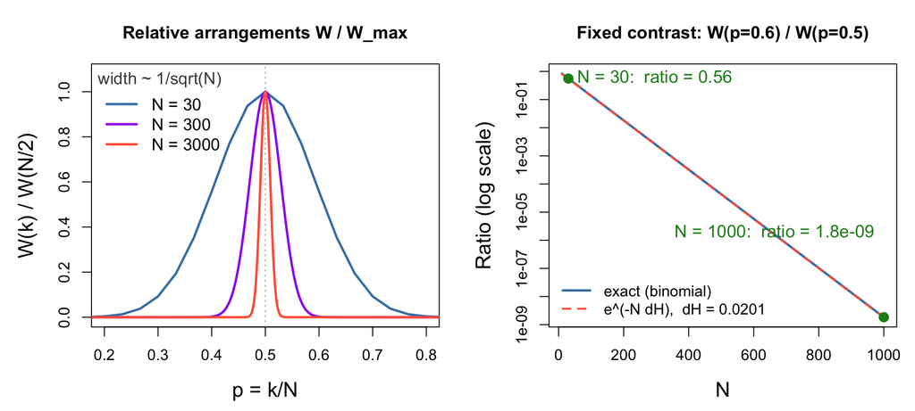

```r
## ── 碾压是 N 的函数：窗口收缩 + 固定 ΔH 的指数塌缩 ──────────

par(mfrow = c(1, 2), mar = c(4.6, 5.0, 3.5, 1))

# 左图：W/W_max 随 N 增大收缩成尖峰（宽度 ~ 1/sqrt(N)）
Ns_w  <- c(30, 300, 3000)
cols_w <- c("steelblue", "purple", "tomato")
plot(NA, xlim = c(0.2, 0.8), ylim = c(0, 1.08),
     main = "Relative arrangements W / W_max",
     xlab = "p = k/N", ylab = "W(k) / W(N/2)",
     cex.lab = 1.35, cex.main = 1.15)
for (i in seq_along(Ns_w)) {
  N_i <- Ns_w[i]
  k_i <- 0:N_i
  rel <- exp(lchoose(N_i, k_i) - lchoose(N_i, round(N_i / 2)))
  lines(k_i / N_i, rel, col = cols_w[i], lwd = 2.5)
}
abline(v = 0.5, col = "gray70", lty = 3)
legend("topleft", paste0("N = ", Ns_w),
       col = cols_w, lwd = 2.5, bty = "n", cex = 1.1,
       title = "width ~ 1/sqrt(N)", title.col = "gray30")

# 右图：固定宏观差异 p=0.6 vs p=0.5，W 比值随 N 指数塌缩
Ns_r <- seq(10, 1000, by = 10)
ratio <- sapply(Ns_r, function(N_i)
  exp(lchoose(N_i, round(0.6 * N_i)) - lchoose(N_i, round(0.5 * N_i))))
plot(Ns_r, ratio, type = "l", lwd = 2.5, col = "steelblue", log = "y",
     main = "Fixed contrast: W(p=0.6) / W(p=0.5)",
     xlab = "N", ylab = "Ratio (log scale)",
     cex.lab = 1.35, cex.main = 1.15)
dH <- (-0.5*log(0.5)-0.5*log(0.5)) - (-0.6*log(0.6)-0.4*log(0.4))
lines(Ns_r, exp(-Ns_r * dH), col = "tomato", lwd = 2, lty = 2)
pts_N <- c(30, 1000)
pts_r <- sapply(pts_N, function(N_i)
  exp(lchoose(N_i, round(0.6 * N_i)) - lchoose(N_i, round(0.5 * N_i))))
points(pts_N, pts_r, pch = 16, col = "forestgreen", cex = 1.5)
text(pts_N[1], pts_r[1], pos = 4,
     paste0("N = 30:  ratio = ", round(pts_r[1], 2)), col = "forestgreen", cex = 1.15)
text(pts_N[2], pts_r[2] * 1e3, pos = 2,
     paste0("N = 1000:  ratio = ", format(pts_r[2], digits = 2)),
     col = "forestgreen", cex = 1.15)
legend("bottomleft", c("exact (binomial)", "e^(-N dH),  dH = 0.0201"),
       col = c("steelblue", "tomato"), lwd = c(2.5, 2), lty = c(1, 2),
       bty = "n", cex = 1.0)
```

左图：把每个 $N$ 的排列数都除以自己的峰值，$N = 30 \to 3000$，窗口按 $1/\sqrt{N}$ 收缩。右图：固定比较 $p = 0.6$ 对 $p = 0.5$（$\Delta H \approx 0.0201$），$W$ 比值在对数轴上是一条直线 $e^{-N\Delta H}$——$N=30$ 时只差一半（0.56，毫不起眼），$N=1000$ 时已是 $10^{-9}$。精确二项计算（蓝）和 $e^{-N\Delta H}$（红虚线）几乎重合。

## 1.3 历史注记：同一个 $H$，两次被发现

上面的推导看着像信息论，历史上却是物理先走通的——$-\sum p_i \ln p_i$ 这个量被独立发现了两次，路径完全不同：

- **1730–1733 年，de Moivre 与 Stirling**：de Moivre 在二项分布近似中得到 $n! \sim C\,n^{n+1/2}e^{-n}$ 的结构；Stirling 在 *Methodus Differentialis*（1730）确定 $C=\sqrt{2\pi}$。de Moivre 随后在 1733 年的小册子里把它用于二项分布的正态近似。工具就位。(Moivre 1733; Stirling 1730)
- **1877 年，Boltzmann**：本节的计数思路直接承接他这年论文——把气体分子的能量切成离散小份，数每种分配的排列数（他称 Komplexionen，即 $W$），再用 Stirling 分析最可能的宏观状态。$S = k_B \ln W$ 后来刻在他的墓碑上；除以 $N$，就出现 $-\sum p_i \ln p_i$ 的形式。(Boltzmann 1877)

  数学在今天看是本科习题，但**公式的难度 ≠ 洞见的难度**——每一步在当时都带有争议：统计解释的第二定律引出 Loschmidt 可逆性与 Zermelo 回归的反驳；原子实在性又遭 Mach、Ostwald 等人质疑。Boltzmann 1906 年自杀，未能亲见 Perrin 随后以布朗运动实验显著推动原子论的接受。Planck 在黑体辐射工作中把离散能量元保留下来，给出了后来标准写法中的常数 $k$ 并以 Boltzmann 命名。(Cercignani 2006; Planck 1901)
- **1948 年，Shannon**（《A Mathematical Theory of Communication》）：走**公理化**路线——要求不确定性度量对 $p$ 连续、等概率时随类别数单调增、分步选择时可加权分解，证明唯一解是 $-K\sum p_i \log p_i$。推导里没有排列数、没有 Stirling；但典型序列又绕回计数：长度 $N$ 的序列里”典型”的约有 $e^{NH}$ 条。(Shannon 1948)
- 命名轶事：后来广为流传的版本称，von Neumann 建议 Shannon 把这个量叫”熵”，因为”没人真正懂熵是什么”。这段话可追溯到 1971 年的转述，而非可核验的谈话记录；把它当作好玩的二手轶事即可。(Tribus and McIrvine 1971)
- **1957 年，Jaynes**（《Information Theory and Statistical Mechanics》）：把两条路正式焊在一起——统计力学的最大熵不是物理定律，而是推断原理的特例。这就是下一小节。(Jaynes 1957)

## 1.4 Jaynes：最大熵 = 最诚实的推断

第二条路不谈物理，谈推断。(Jaynes 1957) 当你只知道一个分布的**部分信息**（比如只知道均值），却要选出一个完整的分布时：

- 选**熵最大**的那个 = 只用上已知的约束，**不夹带任何额外假设**；
- 选其他任何分布 = 偷偷宣称你知道一些其实不知道的信息（比如”分布是双峰的”）。

所以最大熵不是自然界的神秘偏好，而是**约束之外保持最大无知**的唯一一致做法。物理系统”选”它是因为排列数碾压，统计学家”选”它是因为诚实——两条路殊途同归，都指向同一个变分问题：

$$\max_p \; H[p] \quad \text{s.t.
已知约束} \;\Longrightarrow\; p(x) \propto e^{-\lambda
f(x)}$$

后面的第3章到第6章就是把不同的 $f(x)$ 代进去。

**自行观看（拓展）。** [Reinventing Entropy | Compression is Intelligence Part 1](https://www.youtube.com/watch?v=l6DKRf-fAAM)（3Blue1Brown）从压缩的角度重新搭建熵的直觉；它比本文的最大熵主线更宽，可在读完本节后观看。

# 2 熵：为什么是这些分布，而不是别的？

## 2.1 信息熵的定义

对连续分布 $p(x)$，**微分熵**定义为：

$$H[p] = -\int p(x) \ln p(x)\,
dx$$

$H$ 越大，分布越”分散”、越”不确定”、越”没有偏见”。

（这个定义里其实藏了一把”尺子”：所谓”分散”是相对什么在量?连续情形下换个单位，$H$ 的数值就会变。这件事到末章《先说清那把尺子》才需要正面处理，在那之前按常规读法即可。）

**记号注记：为什么信息熵写 $H$ 而不是 $S$。** 这个字母是 Shannon 从 Boltzmann 的 **H 定理**借来的——他在 1948 年的论文里明说了，$H$ 就是 H 定理里那个 $H = \int f\ln f\,dv$（Boltzmann 证明它单调**减**，所以 $S = -k_B H$；Shannon 借了字母、把符号翻了过来）。至于 Boltzmann 为何用 H，一说它本是希腊大写 **Eta（Η）**，因为熵在部分传统里记作小写 $\eta$，而大写 Eta 在印刷上与拉丁 H 无从分辨。

要紧的是两者**不是同一个量**，差着一个 $k_B$ 和量纲：

|  | 记号 | 定义 | 量纲 |
| --- | --- | --- | --- |
| 信息熵（本文主用） | $H$ | $-\sum p\ln p$ | 无量纲（nat；换 $\log_2$ 则为 bit） |
| 热力学熵 | $S$ | $-k_B\sum p\ln p$ | J/K |

$$S = k_B H$$

本文按领域惯例分用两个字母：讲推断时写 $H$，讲热力学（温度、玻尔兹曼分布）时写 $S$，两处用上式换算。物理学界内部也常直接用 $S$ 写这同一个泛函（Gibbs 熵、Tsallis 熵 $S_q$），所以 $H$ 与 $S$ 是**惯例之差，不是对错之分**。另外提醒一句：热化学里的 $H$ 是**焓**，与熵无关，本文完全不涉及。

## 2.2 读懂被积函数：$p(x) \times (-\ln p(x))$

定义里的乘积 $-p\ln p$ 值得拆开看。改写成 $H = \int p(x)\cdot\bigl(-\ln p(x)\bigr)\,dx = E\bigl[-\ln p(X)\bigr]$：

- $-\ln p(x)$ 是在 $x$ 处的**信息量（惊讶度）**：$p$ 越小越惊讶，尾部趋于 $+\infty$；
- $p(x)$ 是**概率权重**：这个惊讶度实际发生的频率；
- 熵 = **平均惊讶度**。

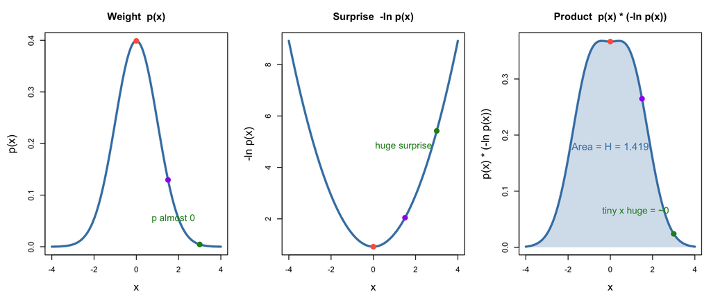

```r
## ── 拆开被积函数：p(x) × (-ln p(x)) ──────────────────────────

x_e  <- seq(-4, 4, length.out = 2000)
p_e  <- dnorm(x_e)          # 概率权重
s_e  <- -log(p_e)           # 信息量（惊讶度）
g_e  <- p_e * s_e           # 熵密度 = 两者乘积

pts      <- c(0, 1.5, 3)    # 三个跟踪点：中心 / 中段 / 尾部
pt_cols  <- c("tomato", "purple", "forestgreen")

par(mfrow = c(1, 3), mar = c(4.6, 4.8, 3.5, 1))

# 面板 1：概率权重 p(x)
plot(x_e, p_e, type = "l", lwd = 3, col = "steelblue",
     main = "Weight  p(x)", xlab = "x", ylab = "p(x)",
     cex.lab = 1.4, cex.main = 1.3)
points(pts, dnorm(pts), pch = 16, col = pt_cols, cex = 1.6)
text(3, dnorm(3) + 0.05, "p almost 0", col = "forestgreen", pos = 2, cex = 1.2)

# 面板 2：信息量 -ln p(x)
plot(x_e, s_e, type = "l", lwd = 3, col = "steelblue",
     main = "Surprise  -ln p(x)", xlab = "x", ylab = "-ln p(x)",
     cex.lab = 1.4, cex.main = 1.3)
points(pts, -log(dnorm(pts)), pch = 16, col = pt_cols, cex = 1.6)
text(3, -log(dnorm(3)) - 0.6, "huge surprise", col = "forestgreen",
     pos = 2, cex = 1.2)

# 面板 3：乘积 = 熵密度，阴影面积 = H
plot(x_e, g_e, type = "l", lwd = 3, col = "steelblue",
     main = "Product  p(x) * (-ln p(x))", xlab = "x",
     ylab = "p(x) * (-ln p(x))", cex.lab = 1.4, cex.main = 1.3)
polygon(c(x_e, rev(x_e)), c(g_e, rep(0, length(g_e))),
        col = adjustcolor("steelblue", 0.25), border = NA)
points(pts, dnorm(pts) * (-log(dnorm(pts))), pch = 16, col = pt_cols, cex = 1.6)
H_val <- 0.5 * log(2 * pi * exp(1))
text(0, 0.18, paste0("Area = H = ", round(H_val, 3)),
    col = "steelblue", cex = 1.3)
text(3, dnorm(3) * (-log(dnorm(3))) + 0.04,
     "tiny x huge = ~0", col = "forestgreen", pos = 2, cex = 1.2)
```

跟踪三个点（标准正态）：

- **红点** $x=0$：权重最大（0.399），但惊讶度最小（0.92）——乘积中等偏大；
- **紫点** $x=1.5$：权重和惊讶度都中等——乘积仍然可观；
- **绿点** $x=3$：惊讶度很大（5.4），但权重几乎为零（0.004）——乘积 $\approx 0$。

尾部不失控是因为 $\lim_{p\to 0} p\ln p = 0$：$p$ 趋于 0 的速度（指数级）永远快过 $\ln p$ 发散的速度（对数级）。所以熵的贡献主要来自”中等概率”区域，第三幅图阴影面积就是 $H = \tfrac{1}{2}\ln(2\pi e) \approx 1.419$。

## 2.3 熵随分布展宽而增大

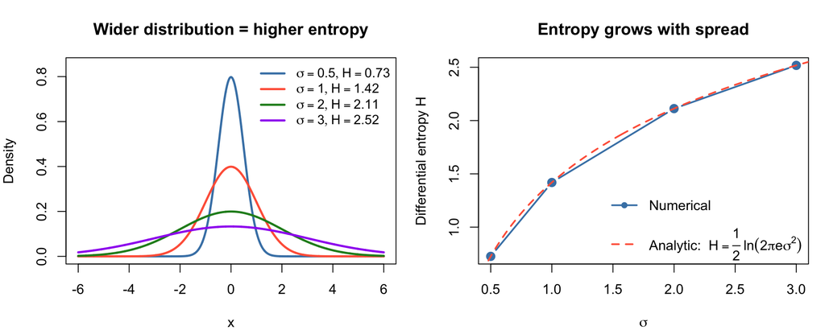

```r
## ── 直觉：熵衡量分布的"展开程度" ──────────────────────────

# 辅助函数：数值计算微分熵
h_diff <- function(p_vals, dx) {
  p_vals <- pmax(p_vals, 1e-300)
  -sum(p_vals * log(p_vals)) * dx
}

x_grid <- seq(-6, 6, length.out = 5000)
dx     <- diff(x_grid)[1]

# 不同 sigma 的正态分布
sigmas  <- c(0.5, 1, 2, 3)
h_vals  <- sapply(sigmas, function(s) h_diff(dnorm(x_grid, 0, s), dx))
h_theory <- 0.5 * log(2 * pi * exp(1) * sigmas^2)

par(mfrow = c(1, 2), mar = c(4, 4, 3.5, 1))

# 左图：分布越宽 → 熵越大
plot(NA, xlim = c(-6, 6), ylim = c(0, 0.85),
     main = "Wider distribution = higher entropy",
     xlab = "x", ylab = "Density")
cols <- c("steelblue", "tomato", "forestgreen", "purple")
for (i in seq_along(sigmas)) {
  lines(x_grid, dnorm(x_grid, 0, sigmas[i]), col = cols[i], lwd = 2.5)
}
legend("topright",
       as.expression(lapply(seq_along(sigmas), function(i)
         bquote(list(sigma == .(sigmas[i]), H == .(round(h_theory[i], 2)))))),
       col = cols, lwd = 2.5, bty = "n", cex = 0.95)

# 右图：sigma vs entropy
plot(sigmas, h_theory, type = "b", pch = 16, col = "steelblue", lwd = 2,
     cex = 1.5, main = "Entropy grows with spread",
     xlab = expression(sigma), ylab = "Differential entropy H")
lines(seq(0.3, 3.2, 0.01),
      0.5 * log(2*pi*exp(1)*seq(0.3,3.2,0.01)^2),
      col = "tomato", lwd = 2, lty = 2)
legend("bottomright",
       expression("Numerical",
                  "Analytic:  " * H == frac(1, 2) ~ ln(2 * pi * e * sigma^2)),
       col = c("steelblue","tomato"), lwd = 2, pch = c(16, NA),
       lty = c(1, 2), bty = "n", y.intersp = 1.4)
```

直觉总结：

- 把概率集中在一个点 → $H \to -\infty$（完全确定，熵最低）
- 均匀展开 → $H$ 最大（完全不确定，熵最高）
- **在有约束的情况下，分布不能完全均匀，但可以在约束允许的范围内尽量”展开”**

## 2.4 最大熵原理

> **当你只知道关于数据的某些统计量（均值、方差……），最诚实的做法是选择满足这些约束、但其他方面尽可能”不做假设”的分布——即熵最大的分布。**

（英文 Maximum Entropy，缩写 MaxEnt，本文图内英文标注用它。）

这不是一个任意的审美偏好，而是一个逻辑必然：

- 如果你选了一个熵更低的分布，你就在**暗中假设**你实际上不知道的信息
- 最大熵分布 = 在约束之外不注入任何额外信息的分布

## 2.5 拉格朗日乘子：零基础版

*本节和下一节（拉格朗日乘子的几何与推导）是纯方法铺垫。如果你已经学过拉格朗日乘子法，或暂时不想看推导，可以放心跳过这两节，直接到《约束决定分布》看结论，甚至直接进入后面的具体分布（从《指数分布》那章开始）——不影响后面的阅读。*

下一小节要用拉格朗日乘子法（Lagrange multipliers），先把这个工具本身讲清楚。核心就一张图，数学只有一行。

**问题形态**。普通极值问题：$f(x,y)$ 哪里最大？——导数为零，$\nabla f = 0$。带约束的极值问题：**在满足 $g(x,y) = c$ 的前提下** $f$ 哪里最大？你只能在约束曲线上走，最优点处 $f$ 的导数一般不是零——只是你被约束拦住了。

**几何直觉（整个方法的灵魂）**。沿约束曲线走，盯着 $f$：

- 若 $\nabla f$（$f$ 增长最快的方向）在曲线切向上**有分量**，沿曲线挪一步就能改进——还没到最优；
- 到了最优点，$\nabla f$ 必须**垂直于约束曲线**（切向分量为零，无路可走）。

而 $\nabla g$ 永远垂直于曲线 $g = c$（沿线 $g$ 不变）。两个向量垂直于同一条曲线 → 平行：

$$\boxed{\nabla f = \lambda\, \nabla
g}$$

$\lambda$ 就是**拉格朗日乘子**——它的全部含义就是”最优点处两个梯度平行”的比例系数。

**操作配方**。构造拉格朗日函数把约束吃进目标函数：

$$L(x, y, \lambda) = f(x,y) -
\lambda\,\bigl(g(x,y) - c\bigr)$$

对所有变量（含 $\lambda$）求偏导设零：前两个方程给出 $\nabla f = \lambda\nabla g$，$\partial L/\partial\lambda = 0$ 自动还原约束。**带约束问题变成了无约束问题**——这就是它好用的原因。

**例**：周长 20 的矩形，面积最大？最大化 $f = xy$，约束 $x + y = 10$：

$$L = xy - \lambda(x + y - 10), \qquad
\frac{\partial L}{\partial x} = y - \lambda = 0, \quad
\frac{\partial L}{\partial y} = x - \lambda = 0
\;\Rightarrow\; x = y = \lambda = 5$$

正方形，面积 25。

下图把这件事画成一座山：曲面是完整的 $f = xy$，整座山一直朝 $(10,10)$ 方向涨上去。**蓝色环线是等高线**（地形图画法，每条线上 $f$ 相同）；$\nabla f$ 的方向由此一眼可读——**垂直穿过等高线、指向更高一环**，这就是最陡上坡方向。**约束线抬升到曲面上是横穿山坡的一条路**（红色），约束优化 = 只许沿这条路走，找路上的最高点。关键看紫色点 $(5,5)$：**$\nabla f$ 在这里并不为零**——绿色箭头垂直于等高线指向上坡，$f$ 还能继续变大，但那个方向离开了约束线，不许走；为零的只是 $\nabla f$ **沿路的切向分量**（右图：路的高度剖面在此处坡度为零）。而在紫色点处约束线恰好与等高线 $f = 25$ **相切**——路贴着等高线走的瞬间，$f$ 不增不减，正是极值。

图中还画了两样东西。**半透明的竖墙**是约束 $g = 10$ 在三维里的形象：$g(x,y) = x+y$ 不含 $z$，所以 $\{x + y = 10\}$ 在三维里是一面 $z$ 自由伸展的墙（这里只画到山体表面为止），**红路就是墙切进山体的截口**；地面虚线是墙脚，即约束集本身。**橙色箭头**是 $\nabla g$ 升维成 $(1,1,0)$ 后的样子：它是这面墙的**唯一法向**——垂直于三维里的一条曲线有无穷多个方向（一整个法平面），但垂直于一张曲面只有一个方向，所以”$\nabla g$ 垂直于约束”用墙来想最不容易误会。地面二维版是同一句话：$\nabla g = (1,1)$ 只有两个分量、出不了地面，在平面内垂直于虚线，方向同样唯一。

**梯度是几维的？** 分量数 = 输入个数。$f(x,y) = xy$ 两个输入，所以 $\nabla f = (y,\ x)$ 是二维向量，$\nabla f(5,5) = (5,\ 5)$；$z = 25$ 是输出，不占分量。图像点 $(5,5,25)$ 在三维，但 $f$ 和它的梯度都住在二维定义域（“地图”）里。方向 $(1,1)$ 给出最陡上坡，模长给出坡度：$|\nabla f| = \sqrt{50} \approx 7.07$，即沿最陡方向水平走 1，$f$ 涨 7.07。

亲手验证一遍。沿 $(1,1)$ 方向走，先归一化成单位向量 $\bigl(\tfrac{1}{\sqrt2}, \tfrac{1}{\sqrt2}\bigr)$（向量 $(1,1)$ 长 $\sqrt2$，不归一化 $t$ 就不是走过的距离），走过距离 $t$ 后位置是 $x(t) = y(t) = 5 + \tfrac{t}{\sqrt2}$，于是：

$$f(t) = x(t)\,y(t) = \Bigl(5 +
\tfrac{t}{\sqrt2}\Bigr)^{2} = 25 + \tfrac{10}{\sqrt2}\,t +
\tfrac{t^2}{2}
\;\Rightarrow\; f'(0) = \tfrac{10}{\sqrt2} = \sqrt{50} \approx 7.07\
\checkmark$$

同一结果也可由方向导数公式一步得到：$\nabla f \cdot \hat u = (5,5)\cdot\bigl(\tfrac{1}{\sqrt2}, \tfrac{1}{\sqrt2}\bigr) = \tfrac{10}{\sqrt2}$——$\hat u$ 与 $\nabla f$ 同向时点积最大，恰为 $|\nabla f|$。“梯度模长 = 最陡坡度”不是定义，是算出来的。

据此校准图例：绿箭头是贴着山坡的可视化向量，其**水平投影**才是 $\nabla f$；$\nabla g$ 画成 $(1,1,0)$ 同理（补 0 入图）。真正三维的梯度属于另一个函数——$F(x,y,z) = z - xy$ 的 $\nabla F = (-y, -x, 1)$，垂直于山坡曲面本身。一般规律：$n$ 元函数的梯度是 $n$ 维向量，垂直于 $(n-1)$ 维等值集。拉格朗日条件用的是 $\nabla f$。

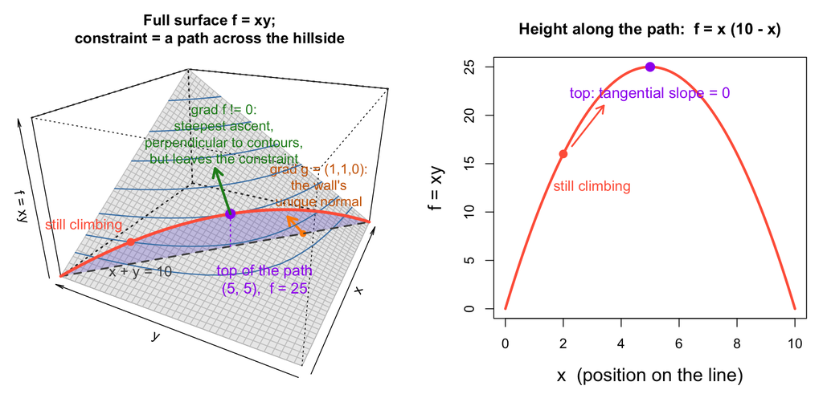

```r
## ── Lagrange 乘子的几何：约束线是曲面上的一条"山路" ──────────

par(mfrow = c(1, 2), mar = c(1, 1, 3.5, 0.5))

# 左图：曲面 z = xy，约束 x + y = 10 抬到曲面上是一条山路
x_s <- seq(0, 10, length.out = 41)
y_s <- seq(0, 10, length.out = 41)
z_s <- outer(x_s, y_s)

pm <- persp(x_s, y_s, z_s, zlim = c(0, 100),
            theta = -63, phi = 24, expand = 0.65,
            col = "gray92", border = "gray78",
            xlab = "x", ylab = "y", zlab = "f = xy",
            main = "Full surface f = xy;\nconstraint = a path across the hillside",
            cex.main = 1.1)

# 补全边框立方体：persp 只画了靠近原点的隐藏边，把 x=10 / y=10 侧补齐
bx <- function(x0, y0, z0, x1, y1, z1)
  lines(trans3d(c(x0, x1), c(y0, y1), c(z0, z1), pm),
        col = "gray20", lty = 3, lwd = 1.8)
bx(10, 10, 0,   10, 10, 100)   # (10,10) 角的竖边
bx(10,  0, 0,   10, 10, 0)     # 底面后边 x = 10
bx( 0, 10, 0,   10, 10, 0)     # 底面后边 y = 10
bx(10,  0, 100, 10, 10, 100)   # 顶面后边 x = 10
bx( 0, 10, 100, 10, 10, 100)   # 顶面后边 y = 10

# 竖墙：g = 10 沿 z 方向延伸（x+y=10, z 自由），墙切山的截口 = 红路
xw <- seq(0, 10, length.out = 120)
wall <- trans3d(c(xw, rev(xw)), c(10 - xw, rev(10 - xw)),
                c(rep(0, 120), rev(xw * (10 - xw))), pm)
polygon(wall$x, wall$y, col = adjustcolor("slateblue", 0.28), border = NA)
# grad g = (1,1,0)：墙的唯一法向（水平，垂直于墙面）
gw <- trans3d(c(7.5, 8.7), c(2.5, 3.7), c(0, 0), pm)
arrows(gw$x[1], gw$y[1], gw$x[2], gw$y[2],
       col = "darkorange", lwd = 3, length = 0.12)
points(trans3d(7.5, 2.5, 0, pm), pch = 16, col = "darkorange", cex = 1.1)
text(trans3d(11.4, 3.0, 12, pm), "grad g = (1,1,0):\nthe wall's\nunique normal",
     col = "darkorange3", cex = 1.0)

# 山体表面的等高线（地形图环线）：grad f 处处垂直于它们
cls <- contourLines(x_s, y_s, z_s, levels = c(9, 16, 25, 36, 49, 64, 81))
for (cl in cls) lines(trans3d(cl$x, cl$y, cl$level, pm), col = "steelblue", lwd = 1.4)

x_p <- seq(0, 10, length.out = 200)
# 约束线（地面上）
lines(trans3d(x_p, 10 - x_p, 0, pm), col = "gray30", lwd = 2, lty = 2)
# 山路：约束线抬升到曲面上，高度 f = x(10-x)
lines(trans3d(x_p, 10 - x_p, x_p * (10 - x_p), pm), col = "tomato", lwd = 3.5)
# 非最优点 (2,8) 与最优点 (5,5)
points(trans3d(2, 8, 16, pm), pch = 16, col = "tomato", cex = 1.3)
points(trans3d(5, 5, 25, pm), pch = 16, col = "purple", cex = 1.7)
# 最优点垂线
lines(trans3d(c(5, 5), c(5, 5), c(0, 25), pm), col = "purple", lty = 3, lwd = 1.5)
# grad f 在 (5,5) 不为零：指向上坡（离开约束线）
gr <- trans3d(c(5, 6.6), c(5, 6.6), c(25, 6.6^2), pm)
arrows(gr$x[1], gr$y[1], gr$x[2], gr$y[2], col = "forestgreen", lwd = 3, length = 0.12)
text(trans3d(5.6, 5.6, 76, pm),
     "grad f != 0:\nsteepest ascent,\nperpendicular to contours,\nbut leaves the constraint",
     col = "forestgreen", cex = 1.0)
text(trans3d(2.2, 2.2, 16, pm), "top of the path\n(5, 5),  f = 25", col = "purple", cex = 1.1)
text(trans3d(1.0, 9.4, 30, pm), "still climbing", col = "tomato", cex = 1.05)
text(trans3d(2.2, 7.8, -8, pm), "x + y = 10", col = "gray30", cex = 1.05)

# 右图：沿约束线走，f 的值 = x(10-x)（山路的侧面展开）
par(mar = c(4.6, 5.0, 3.5, 1))
x_c <- seq(0, 10, length.out = 300)
plot(x_c, x_c * (10 - x_c), type = "l", lwd = 3, col = "tomato",
     main = "Height along the path:  f = x (10 - x)",
     xlab = "x  (position on the line)", ylab = "f = xy",
     cex.lab = 1.35, cex.main = 1.15)
points(5, 25, pch = 16, col = "purple", cex = 1.6)
points(2, 16, pch = 16, col = "tomato", cex = 1.4)
arrows(2.3, 16.8, 3.4, 21, col = "tomato", lwd = 2, length = 0.1)
text(3.0, 12.6, "still climbing", col = "tomato", cex = 1.05)
text(5, 22.2, "top: tangential slope = 0", col = "purple", cex = 1.1)
```

**$\lambda$ 的含义：约束的”价格”**。一个漂亮的定理：最优值对约束的敏感度就是乘子本身，

$$\frac{df^*}{dc} = \lambda$$

上例 $\lambda = 5$：周长的一半从 10 放松到 11，最大面积涨约 5（精确值 $5.5^2 - 5^2 = 5.25$）。（$\lambda$ 的数值绑定在约束的写法上：把 $g$ 乘 2，$\lambda$ 减半，$df^*/dc$ 同步减半，定理在任何写法下自洽；量纲是 $[f]/[g]$。）

这个”约束的价格”在各领域都有自己的名字：

| 领域 | $\lambda$ 的名字 | 例子 |
| --- | --- | --- |
| 优化/数学 | 对偶变量、KKT 乘子 | 线性规划对偶问题的解 |
| 分析力学 | **约束力** | 钢丝给珠子的法向支持力、绳的张力 |
| 统计物理 | **共轭强度量** | $\beta = 1/k_BT$（能量约束） |
| 化学 | **化学势** $\mu$ | 粒子数约束 |
| 经济学 | 影子价格 | 预算约束 = 边际效用 |

力学那行最直观：小球被约束在斜面上，拉格朗日方程解出的 $\lambda$ **就是斜面顶住小球的法向力**——“支持力垂直于接触面”和”$\nabla g$ 垂直于约束集”是同一句话。热力学的强度量–广延量配对表（$T$–$S$、$p$–$V$、$\mu$–$N$）本质上是一张拉格朗日乘子登记表：每个强度量都是某个守恒量约束的乘子，这也是它们天生不随系统变大的原因——乘子是比率 $\partial f^*/\partial c$。《玻尔兹曼分布》那章会看到其中第一行：温度就是能量约束的影子价格，$\partial S/\partial E = 1/T$。

**推广到分布**：最大熵问题里”变量”不是两个数，而是每一点的密度值 $p(x)$——无穷多个变量，每个 $x$ 一个。配方不变（这一步叫变分法），下一小节就做这件事。物理里这套方法无处不在，因为物理问题几乎全是”某量取极值 + 守恒律当约束”，而乘子往往就是有名字的物理量：温度（能量约束）、化学势（粒子数约束）、压强（体积约束）。

## 2.6 拉格朗日乘子推导：分布的一般形式

最大化 $H = -\int p \ln p\, dx$，约束条件：

1. 归一化：$\int p(x) dx = 1$
2. 某个函数的期望值固定：$\int p(x) f(x) dx = \langle f \rangle$

（约束 2 不是推导出来的，是**问题的输入**：你测到或守恒律给定了某个平均量，“知道一个平均量”写成数学就是期望值形式——$f(x)$ 指明**测的是什么量**，$\langle f\rangle$ 是**测出来的那个数**。对照：

- 测到样本均值 $\bar x$：取 $f(x) = x$，约束为 $\int p(x)\,x\,dx = \bar x$，即 $\langle f\rangle = \bar x$；
- 测到方差 $s^2$（连同均值 $\bar x$）：再加一条 $f(x) = x^2$，约束为 $\int p(x)\,x^2\,dx = s^2 + \bar x^2$（二阶矩），即 $\langle f\rangle = s^2 + \bar x^2$；
- 能量守恒、平均每个粒子分到 $\bar E$：取 $f(x) = E(x)$，约束为 $\int p(x)\,E(x)\,dx = \bar E$，即 $\langle f\rangle = \bar E$。

$f$ 和 $\langle f\rangle$ 都由已知信息决定，最大熵原理只负责已知之外不多假设——所以换一个 $f$ 就换一个分布。）

构造拉格朗日函数：

$$L = -\int p \ln p\, dx -
\lambda_0\!\left(\int p\, dx - 1\right) - \lambda_1\!\left(\int p\,
f(x)\, dx - \langle f\rangle\right)$$

对 $p(x)$ 求变分并令其为零：

**“求变分”是什么意思？** 普通微积分优化一个**数**，这里优化一整条**函数**（找哪条 $p$ 让 $H[p]$ 最大）——这就是变分法。实操上只需一条规则：被积函数 $F(p)$ 对 $p$ 当普通变量求导即可，

$$\frac{\delta}{\delta p(x)} \int F(p)\,
dx = \frac{\partial F}{\partial p}$$

用到熵项：$F = p\ln p$，$\frac{\partial}{\partial p}(p\ln p) = \ln p + 1$（乘积法则，$+1$ 来自 $p\cdot\frac{1}{p}$）。所以 $-\int p\ln p$ 贡献 $-\ln p - 1$，归一化项贡献 $-\lambda_0$，期望项贡献 $-\lambda_1 f(x)$，相加即下式。（$+1$ 最后并进 $Z = e^{1+\lambda_0}$，不影响解。）

$$\frac{\delta L}{\delta p} = -\ln p(x) -
1 - \lambda_0 - \lambda_1 f(x) = 0$$

解出：

$$\boxed{p(x) = \frac{1}{Z}\,
e^{-\lambda_1 f(x)}}$$

其中 $Z = e^{1+\lambda_0}$ 是归一化常数（配分函数），$\lambda_1$ 由约束 $\langle f\rangle$ 决定。

**这就是全部的推导。** 所有分布都从这一个公式出来，区别只在于 $f(x)$ 是什么。

## 2.7 约束决定分布

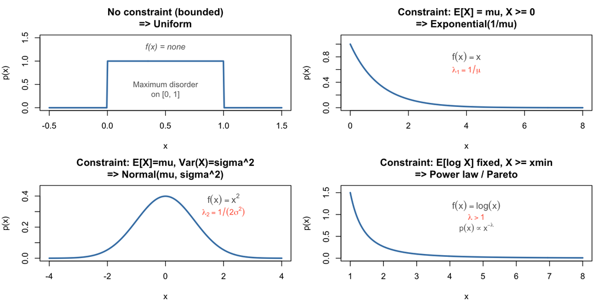

| 约束 | $f(x)$ | $\lambda$ | 最大熵分布 $p(x)$ |
| --- | --- | --- | --- |
| 无约束（有界） | — | — | Uniform：$\dfrac{1}{b-a}$ |
| $E[X] = \mu$，$X \geq 0$ | $x$ | $1/\mu$ | Exponential：$\lambda e^{-\lambda x}$ |
| $E[\ln X]$ 固定，$X \geq x_{\min}$ | $\ln x$ | $\lambda > 1$ | Power law：$(\lambda-1)x_{\min}^{\lambda-1}x^{-\lambda}$ |
| $E[X] = \mu$，$\text{Var}(X) = \sigma^2$ | $x^2$ | $1/(2\sigma^2)$ | Normal：$\dfrac{1}{\sqrt{2\pi}\,\sigma}\,e^{-(x-\mu)^2/(2\sigma^2)}$ |
| $E[\text{Energy}] = \langle E \rangle$ | $E$ | $\beta = 1/k_BT$ | Boltzmann：$\beta\, e^{-\beta E}$ |

```r
par(mfrow = c(2, 2), mar = c(4, 4, 3.5, 1))

# ── 1. 无约束（有界区间） → Uniform ──
x1 <- seq(-0.5, 1.5, length.out = 300)
plot(x1, dunif(x1, 0, 1), type = "l", col = "steelblue", lwd = 2.5,
     main = "No constraint (bounded)\n=> Uniform",
     xlab = "x", ylab = "p(x)", ylim = c(0, 1.5))
text(0.5, 1.3, "f(x) = none", font = 3, col = "gray40")
text(0.5, 0.4, "Maximum disorder\non [0, 1]", col = "gray40", cex = 0.95)

# ── 2. 固定均值（非负） → Exponential ──
x2 <- seq(0, 8, length.out = 300)
plot(x2, dexp(x2, rate = 1), type = "l", col = "steelblue", lwd = 2.5,
     main = "Constraint: E[X] = mu, X >= 0\n=> Exponential(1/mu)",
     xlab = "x", ylab = "p(x)", ylim = c(0, 1.1))
text(4, 0.8, expression(f(x) == x), font = 3, col = "gray40", cex = 1.1)
text(4, 0.6, expression(lambda[1] == 1/mu), col = "tomato", cex = 0.95)

# ── 3. 固定均值 + 方差 → Normal ──
x3 <- seq(-4, 4, length.out = 300)
plot(x3, dnorm(x3), type = "l", col = "steelblue", lwd = 2.5,
     main = "Constraint: E[X]=mu, Var(X)=sigma^2\n=> Normal(mu, sigma^2)",
     xlab = "x", ylab = "p(x)", ylim = c(0, 0.45))
text(2, 0.38, expression(f(x) == x^2), font = 3, col = "gray40", cex = 1.1)
text(2, 0.30, expression(lambda[2] == 1/(2*sigma^2)), col = "tomato", cex = 0.95)

# ── 4. 固定对数均值 → Power law / Pareto ──
x4 <- seq(1, 8, length.out = 300)
lambda4 <- 2.5
xmin4 <- 1
p4 <- (lambda4 - 1) * xmin4^(lambda4 - 1) * x4^(-lambda4)
plot(x4, p4, type = "l", col = "steelblue", lwd = 2.5,
     main = "Constraint: E[log X] fixed, X >= xmin\n=> Power law / Pareto",
     xlab = "x", ylab = "p(x)", ylim = c(0, 1.6))
text(4.8, 1.20, expression(f(x) == log(x)), font = 3, col = "gray40", cex = 1.1)
text(4.8, 0.95, expression(lambda > 1), col = "tomato", cex = 0.95)
text(4.8, 0.70, expression(p(x) %prop% x^-lambda), col = "gray40", cex = 0.95)
```

**所有这些分布来自同一个方程的不同解。** 区别只在于你”知道什么”（约束）。这里的”约束”不只包括均值、方差、能量这类期望条件，也包括**支撑集**本身：均匀分布要先知道变量被限制在 $[a,b]$，指数分布要先知道 $X\ge0$，幂律分布要先知道 $X\ge x_{\min}>0$。最大熵问题从来不是”凭空找一个分布”，而是：

$$\text{给定支撑集 + 给定若干统计量}
\quad\Longrightarrow\quad \text{在这些信息内熵最大}$$

# 3 指数分布 = 最大熵 + 非负 + 均值约束

## 3.1 推导

约束：$X \geq 0$，$E[X] = \mu$。这里 $X\ge0$ 本身就是一条**支撑约束**：等待时间、寿命、高度、能量这类量不能为负；在这个半轴上再固定均值，才得到指数分布。代入通解：

$$p(x) = \frac{1}{Z} e^{-\lambda x} =
\lambda e^{-\lambda x}, \quad \lambda = 1/\mu$$

归一化常数 $Z = 1/\lambda$。微分熵 $H = -\int_0^\infty p\ln p\,dx$：

$$\begin{aligned}
H &= -\int_0^\infty \lambda e^{-\lambda x}\,\ln\!\bigl(\lambda
e^{-\lambda x}\bigr)\,dx \\[2pt]
&= -\int_0^\infty \lambda e^{-\lambda x}\,(\ln\lambda - \lambda
x)\,dx
&& \ln\bigl(\lambda e^{-\lambda x}\bigr) = \ln\lambda -
\lambda x \\[2pt]
&= -\ln\lambda \int_0^\infty p\,dx \;+\; \lambda \int_0^\infty
x\,p\,dx
&& \text{拆开，}p = \lambda e^{-\lambda x} \\[2pt]
&= -\ln\lambda \cdot 1 \;+\; \lambda \cdot \tfrac{1}{\lambda}
&& \textstyle\int p\,dx = 1,\ \int x\,p\,dx = E[X] = 1/\lambda
\\[2pt]
&= 1 - \ln\lambda = 1 + \ln\mu
&& \mu = 1/\lambda
\end{aligned}$$

单位是 nat（用 $\ln$）。均值越大分布越展开，$H$ 随之增大；$\mu < 1/e$ 时 $H < 0$——微分熵可负，与离散熵不同。

## 3.2 数值验证：候选分布中，指数的熵最高

在均值 $= 2$ 的所有非负分布中比较熵：

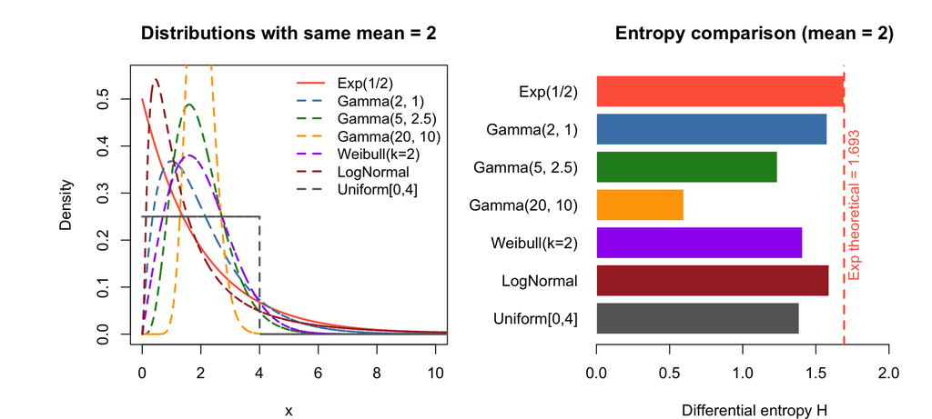

```r
# 在 [0, max] 网格上数值计算微分熵
x_pos <- seq(0.001, 20, length.out = 8000)
dx_p  <- diff(x_pos)[1]

h_pos <- function(p_vals) {
  p_vals <- pmax(p_vals, 1e-300)
  p_norm <- p_vals / (sum(p_vals) * dx_p)
  -sum(p_norm * log(p_norm)) * dx_p
}

mu <- 2   # 固定均值

# 均值 = 2 的各种分布
dists <- list(
  "Exp(1/2)"         = dexp(x_pos, rate = 1/mu),
  "Gamma(2, 1)"      = dgamma(x_pos, shape = 2,  rate = 2/mu),
  "Gamma(5, 2.5)"    = dgamma(x_pos, shape = 5,  rate = 5/mu),
  "Gamma(20, 10)"    = dgamma(x_pos, shape = 20, rate = 20/mu),
  "Weibull(k=2)"     = dweibull(x_pos, shape = 2,
                                scale = mu / gamma(1 + 1/2)),
  "LogNormal"        = dlnorm(x_pos, meanlog = log(mu) - 0.5, sdlog = 1),
  "Uniform[0,4]"     = dunif(x_pos, 0, 2 * mu)   # 均值 2 的均匀分布：熵反而更小
)

entropies <- sapply(dists, h_pos)
h_theory  <- 1 + log(mu)   # Exp(1/mu) 的解析熵

par(mfrow = c(1, 2), mar = c(4, 7, 3.5, 1))

# 左图：密度对比
plot(NA, xlim = c(0, 10), ylim = c(0, 0.55),
     main = "Distributions with same mean = 2",
     xlab = "x", ylab = "Density")
dist_cols <- c("tomato", "steelblue", "forestgreen", "orange", "purple", "brown", "gray40")
for (i in seq_along(dists)) {
  lines(x_pos, dists[[i]], col = dist_cols[i], lwd = 2,
        lty = ifelse(i == 1, 1, 2))
}
legend("topright", names(dists), col = dist_cols, lwd = 2,
       lty = c(1, rep(2, 6)), bty = "n", cex = 0.95)

# 右图：熵的比较（横向条形图）
barplot(rev(entropies), horiz = TRUE, col = rev(dist_cols),
        border = "white", las = 1, xlim = c(0, max(entropies) * 1.28),
        main = "Entropy comparison (mean = 2)",
        xlab = "Differential entropy H")
abline(v = h_theory, col = "tomato", lwd = 2, lty = 2)
text(h_theory * 1.045, 4.3, paste("Exp theoretical =", round(h_theory, 3)),
     col = "tomato", adj = 0.5, srt = 90, cex = 0.95)
```

**Exp(1/2) 的红色条最长——在均值 $= 2$ 的所有非负分布中，指数分布的熵确实最大。**

Gamma(k) 随着 $k$ 增大（形状越像正态），熵越来越低，因为分布越来越”确定”。

注意最下面那条 **Uniform[0,4]**（均值也是 2）：它的熵 $\ln 4 \approx 1.386$，**比指数的 $1.693$ 还小**。这看着反直觉——“均匀 = 最大熵”不是常说的吗？那条结论只在**支撑集固定有界、且无其他约束**时成立（“$X$ 一定在 $[0,4]$ 内，别的不知道”→ 均匀）。这里支撑是整个 $[0,\infty)$、约束是均值：$U[0,4]$ 在 $x>4$ 处概率**硬性为零**，等于偷偷断言”$X$ 绝不超过 4”——一条你并不知道的额外信息，反而**扣熵**。指数不设上限、铺满半轴，除均值外不假设任何东西，所以熵更高。

## 3.3 严格证明：固定均值下，指数熵最大（不只是”图上最高”）

上图只比了 7 条。要证的命题是：**在均值固定为 $\mu$ 的前提下，所有非负分布里指数的熵最大**（“固定均值”不能省——不加约束时熵没有上界）。用 Gibbs 不等式：对 $[0,\infty)$ 上任意均值为 $\mu$ 的密度 $p$，取同均值的指数 $q(x)=\tfrac1\mu e^{-x/\mu}$，其 KL 散度非负（$\int p\ln\frac{p}{q}\ge 0$），展开：

（这是”猜答案再验证”：$q$ 不是凭空取的——它正是 2.6 变分推出的候选；换个角度，它也是唯一能让下面交叉熵项塌成常数的 $q$，见《细节》。）

$$\begin{aligned}
0 \le \int p\ln\frac{p}{q}\,dx
&= \int p\ln p\,dx - \int p\ln q\,dx
&& \ln\tfrac{p}{q} = \ln p - \ln q \\[2pt]
&= -H(p) - \int p\ln q\,dx
&& H(p) = -\!\int p\ln p\,dx \\[2pt]
&= -H(p) - \int p\Bigl(-\ln\mu - \tfrac{x}{\mu}\Bigr)dx
&& \ln q = -\ln\mu - x/\mu \\[2pt]
&= -H(p) + \ln\mu + \tfrac{1}{\mu}\!\int x\,p\,dx
&& \textstyle\int x\,p\,dx = \mu \\[2pt]
&= -H(p) + \ln\mu + 1
\end{aligned}$$

移项即 $H(p) \le 1 + \ln\mu = H(q)$，等号仅当 $p = q$。固定均值下，指数是唯一的最大熵解——不是图里凑巧最高。

**两条路的分工**（贯穿全文的关键）：求最大熵分布分两步——2.6 的**变分/拉格朗日负责”找出”**候选 $p\propto e^{-\lambda f}$（但变分只给驻点，不自动保证是全局最大）；这里的 **Gibbs 不等式负责”证明”它是唯一的全局最大**——对所有同约束分布 $H(p)\le H(q)$，且等号**仅**当 $p=q$，所以任何别的分布都**严格**更小，指数是唯一达到最大的那个（代价是需要候选作输入）。一句话：**变分找出它，Gibbs 盖章**。

下面的《细节》解释这里用到的 KL 散度、以及为什么取指数作 $q$。只想要结论的话，可以直接跳到下一节《无记忆性》。

### 3.3.1 细节：KL 散度与两个选择

**KL 散度是什么。** 两个密度 $p$、$q$ 之间的 KL 散度 $D(p\|q) = \int p\ln\frac{p}{q}\,dx$，读成”用 $q$ 描述真实分布 $p$ 时平均多付的对数代价”。这个”代价”有实在背景：香农编码给概率 $p(x)$ 的符号分配 $-\log_2 p(x)$ 比特，按真实 $p$ 编码平均码长最短（$=H(p)$）；若误以为分布是 $q$、按 $q$ 造码，每个符号平均多花的比特数恰好就是 $D(p\|q)$——用错模型永远不会更省，所以它 $\ge 0$。机器学习里的**交叉熵损失**正是这个量：训练分类器 = 让模型分布 $q$ 逼近真实标签 $p$，即最小化 $D(p\|q)$。它**永远非负，等号仅当 $p=q$**：

**自行观看（拓展）。** [But what is cross-entropy? | Compression is Intelligence Part 2](https://www.youtube.com/watch?v=GlYgs6v2YfU)（3Blue1Brown）把交叉熵、编码代价与机器学习损失连成一条线；读完上面的编码解释再看最合适。

$$-D(p\|q) = \int p\ln\frac{q}{p}\,dx =
E_p\Bigl[\ln\tfrac{q}{p}\Bigr] \;\overset{\text{Jensen}}{\le}\; \ln
E_p\Bigl[\tfrac{q}{p}\Bigr] = \ln\!\int p\cdot\frac{q}{p}\,dx =
\ln\!\int q\,dx = 0$$

那步 Jensen 不等式说的是：**对凹函数（concave，∩ 形、开口朝下，如 $\ln$），“先平均、再取函数值” $\ge$ “先取函数值、再平均”**，即 $\varphi(E[X]) \ge E[\varphi(X)]$。几何上，凹函数的任意弦都在曲线下方，所以曲线在”平均点”处的高度高于两端函数值的平均。（注意别被汉字坑：字形”凹”像 ∪，但凹/concave 函数是 ∩；“凸”/convex 反而是 ∪ 形，如 $x^2$。盯例子别盯字。）$\ln$ 处处凹（$\ln'' x = -1/x^2 < 0$），故 $\ln E[Y] \ge E[\ln Y]$；这里取 $Y = q/p$、期望按 $p$ 算，把 $\ln$ 提到期望外只会让值变大，得到 $\le \ln E_p[q/p] = \ln\!\int q = \ln 1 = 0$。于是 $-D \le 0$，即 $D \ge 0$。

**为什么用 KL。** 它恒 $\ge 0$，是把”$=$“撬成”$\le$“的现成工具。上面第一行拆开就得 $H(p) \le -\int p\ln q$，右边是**交叉熵**——熵不超过用任意 $q$ 算的交叉熵。剩下的只是把交叉熵算出来。

**为什么取指数。** 一般的 $q$ 交叉熵算不动。指数的 $\ln q = -\ln\mu - x/\mu$ 对 $x$ **线性**，于是交叉熵里只出现 $\int x\,p = p$ 的均值 $=\mu$（已固定）——它不再依赖 $p$ 的其他细节，对每个均值 $\mu$ 的 $p$ 都塌成同一个常数 $\ln\mu+1 = H(q)$。起作用的正是 $f(x)=x$ 的**线性**（2.6 通解里的 $f$）。

**通用配方。** 换约束换 $q$，同一个证明照走：约束 $\int f\,p = c$ → 取 $q \propto e^{-\lambda f}$（$\ln q$ 对 $f$ 线性）→ 交叉熵只看 $\int f\,p = c$ → 塌成常数。$f=x\to$ 指数，$f=x^2\to$ 正态，$f=E\to$ 玻尔兹曼。这也说明”变分找出、Gibbs 盖章”这套分工对每个分布都成立，不止指数。

## 3.4 性质：无记忆性

指数分布还有一个独立于最大熵的特殊性质：**唯一满足无记忆性的连续分布**。

$$P(X > s + t \mid X > s) = P(X >
t) \quad \forall\, s, t > 0$$

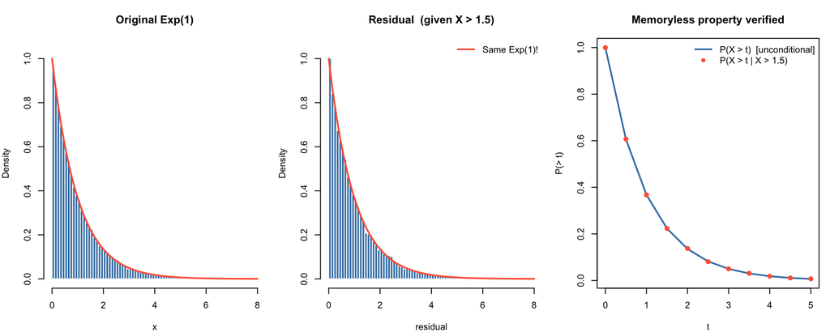

```r
X_mem    <- rexp(N, rate = 1)
s        <- 1.5
residual <- X_mem[X_mem > s] - s

par(mfrow = c(1, 3), mar = c(4, 4, 3.5, 1))

hist(X_mem, breaks = 100, freq = FALSE, col = "steelblue", border = "white",
     main = "Original Exp(1)", xlab = "x", xlim = c(0, 8), ylim = c(0, 1.05))
curve(dexp(x, 1), add = TRUE, col = "tomato", lwd = 2)

hist(residual, breaks = 100, freq = FALSE, col = "steelblue", border = "white",
     main = paste0("Residual  (given X > ", s, ")"),
     xlab = "residual", xlim = c(0, 8), ylim = c(0, 1.05))
curve(dexp(x, 1), add = TRUE, col = "tomato", lwd = 2)
legend("topright", "Same Exp(1)!", col = "tomato", lwd = 2, bty = "n")

t_vals      <- seq(0, 5, by = 0.5)
p_original  <- pexp(t_vals, lower.tail = FALSE)
p_condition <- sapply(t_vals, function(t) mean(residual > t))
plot(t_vals, p_original, type = "l", col = "steelblue", lwd = 2,
     main = "Memoryless property verified",
     xlab = "t", ylab = "P(> t)")
points(t_vals, p_condition, col = "tomato", pch = 16, cex = 1.2)
legend("topright",
       c("P(X > t)  [unconditional]",
         paste0("P(X > t | X > ", s, ")")),
       col = c("steelblue", "tomato"), lwd = c(2, NA), pch = c(NA, 16), bty = "n")
```

**数学本质**：$P(X > t) = e^{-\lambda t}$——指数函数的”每增加一点、概率按固定比例下降”直接蕴含无记忆性。

## 3.5 物理实例：等温大气与放射性衰变

**等温大气公式**。一个空气分子在高度 $h$ 处的重力势能是 $E = mgh$——**能量随高度线性**。这正是”线性约束 → 指数”的实物版，Boltzmann 因子直接给出：

$$P(h) \propto e^{-mgh/k_BT}$$

标高 $H_{\text{scale}} = k_BT/mg \approx 8.5$ km（地球大气，$T \approx 288$ K；大气物理里通常直接记作 $H$，本文加下标以免与熵的 $H$ 撞名）：每升高 8.5 km，气压掉到 $1/e$。这也是《玻尔兹曼分布》那章的预告——同一个公式，那里换成能级。

**放射性衰变**。原子核不老化：一个已经存在了一万年的 $^{14}$C 核，接下来一秒衰变的概率和刚生成的核完全一样——这就是上一小节的**无记忆性**，所以寿命只能服从指数分布。半衰期 $t_{1/2} = \ln 2/\lambda$ 等间距地把存活比例砍半：$1/2, 1/4, 1/8, \dots$。化学里的一级反应动力学（$-d[A]/dt = k[A]$）和荧光寿命衰减是同一个数学。

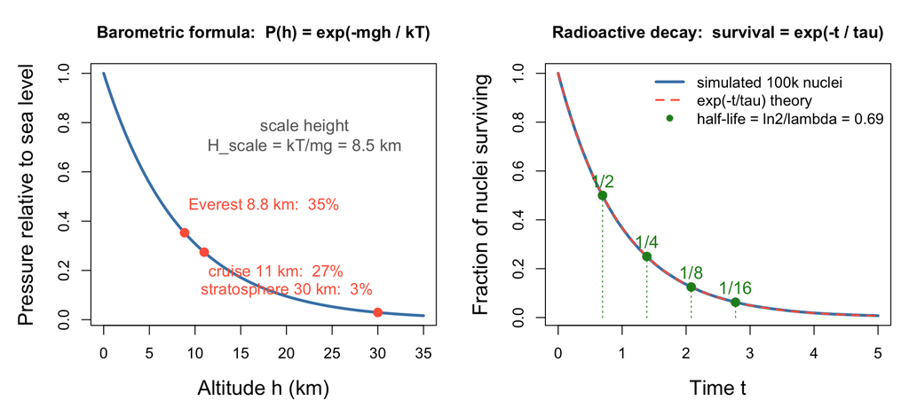

```r
## ── 物理实例：等温大气 + 放射性衰变 ──────────────────────────

par(mfrow = c(1, 2), mar = c(4.6, 5.0, 3.5, 1))

# 左图：等温大气公式 P(h) = exp(-h/H)，H = kT/mg ≈ 8.5 km
h_seq <- seq(0, 35, length.out = 400)
H_scale <- 8.5   # km，地球大气标高
plot(h_seq, exp(-h_seq / H_scale), type = "l", lwd = 3, col = "steelblue",
     main = "Barometric formula:  P(h) = exp(-mgh / kT)",
     xlab = "Altitude h (km)", ylab = "Pressure relative to sea level",
     cex.lab = 1.35, cex.main = 1.1)
landmarks <- data.frame(h = c(8.85, 11, 30))
points(landmarks$h, exp(-landmarks$h / H_scale), pch = 16, col = "tomato", cex = 1.4)
text(9.3,  0.47, "Everest 8.8 km:  35%",      col = "tomato", adj = 0, cex = 1.05)
text(11.5, 0.20, "cruise 11 km:  27%",        col = "tomato", adj = 0, cex = 1.05)
text(29.5, 0.12, "stratosphere 30 km:  3%",   col = "tomato", adj = 1, cex = 1.05)
text(22, 0.75, "scale height\nH_scale = kT/mg = 8.5 km", col = "gray40", cex = 1.1)

# 右图：放射性衰变，存活曲线 + 等间距半衰期
lam    <- 1                       # 衰变常数
t_half <- log(2) / lam
lifetimes <- rexp(N, rate = lam)  # 模拟 N 个原子核的寿命
t_seq  <- seq(0, 5, length.out = 300)
surv_sim <- sapply(t_seq, function(t) mean(lifetimes > t))
plot(t_seq, surv_sim, type = "l", lwd = 3, col = "steelblue",
     main = "Radioactive decay:  survival = exp(-t / tau)",
     xlab = "Time t", ylab = "Fraction of nuclei surviving",
     cex.lab = 1.35, cex.main = 1.1)
curve(exp(-lam * x), add = TRUE, col = "tomato", lwd = 2, lty = 2)
halves <- t_half * (1:4)
points(halves, 0.5^(1:4), pch = 16, col = "forestgreen", cex = 1.4)
segments(halves, 0, halves, 0.5^(1:4), col = "forestgreen", lty = 3)
text(halves, 0.5^(1:4) + 0.06,
     c("1/2", "1/4", "1/8", "1/16"), col = "forestgreen", cex = 1.15)
legend("topright",
       c("simulated 100k nuclei", "exp(-t/tau) theory",
         paste0("half-life = ln2/lambda = ", round(t_half, 2))),
       col = c("steelblue", "tomato", "forestgreen"),
       lwd = c(3, 2, NA), lty = c(1, 2, NA), pch = c(NA, NA, 16),
       bty = "n", cex = 1.0)
```

### 3.5.1 决定形状的是 $f(x)$ 的形式

这两个例子给出指数分布，根源都在通解 $p(x) \propto e^{-\lambda f(x)}$ 里 **$f(x)$ 的形式**——$\ln p$ 对 $x$ 是几次函数，就得到哪个分布：

$$f(x) = x\ (\text{线性}) \to \text{指数},
\qquad f(x) = x^2 \to \text{半正态}, \qquad \dots$$

“只约束均值”写成数学就是 $\int x\,p\,dx = \mu$，即 $f(x) = x$ 线性——这一步逼出指数。换一个被约束的量，形状就变：在同样的 $[0,\infty)$ 上若约束二阶矩（$f(x) = x^2$），得到的是半正态 $p \propto e^{-\lambda x^2}$。可见拍板的是**被约束量对 $x$ 的函数形式**，而不是约束或参数的个数——单看”只有一个尺度参数”并不足以定出指数（Rayleigh、半正态也都是 $[0,\infty)$ 上的单参数分布）。

两个例子的线性各有来源：

- **等温大气**：势能 $E = mgh$ 对高度线性 → 指数。若势能 $\propto h^2$，同一个温度参数给出的会是高斯。
- **放射性衰变**：对应的线性条件是**恒定风险率**（单位时间衰变概率不随年龄变），也就是无记忆性——$\ln(\text{存活率}) = -\lambda t$ 对 $t$ 线性。

一句话：**指数 $\Leftrightarrow \ln p$ 对 $x$ 线性 $\Leftrightarrow$ 恒定风险率 $\Leftrightarrow$ 无记忆**。指数、正态、玻尔兹曼的分别，就是 $\ln p$ 各为 $x$ 的一次、二次、能量函数——回到 2.6 节的通解。

# 4 幂律分布 = 最大熵 + 对数均值约束

幂律分布 $p(x) \propto x^{-\lambda}$ 在自然界随处可见——地震能量、城市人口、词频、财富、网站链接数、物种多度……但课堂上很少讲它**为什么**出现，更少讲它和指数、正态的内在关系。答案出奇地简洁：**同一个最大熵框架，只要换一个约束函数，就吐出幂律**。前面指数约束的是算术均值 $\langle x\rangle$、正态约束的是方差，这里约束的是**对数均值** $\langle\ln x\rangle$，等价于固定几何均值 $e^{E[\ln X]}$。

## 4.1 推导

约束：$x \ge x_{\min} > 0$，且**对数的均值**固定：

$$E[\ln X] = m \qquad (m > \ln
x_{\min})$$

取约束函数 $f(x) = \ln x$，代入通解：

$$p(x) = \frac{1}{Z}\, e^{-\lambda \ln x}
= \frac{1}{Z}\, x^{-\lambda}$$

这就是幂律。$\ln p = -\lambda\ln x - \ln Z$ 对 $\ln x$ 线性——所以幂律在**双对数坐标**上是一条直线，斜率 $-\lambda$。这条 log-log 直线正是”$\ln p$ 对被约束量 $\ln x$ 线性”的字面画面，和指数在 lin-log 上是直线完全平行。

**归一化需要下限 $x_{\min}$。** 幂律和指数一样，都不是全实轴上的自由分布：指数的自然支撑是 $[0,\infty)$，幂律的自然支撑是 $[x_{\min},\infty)$。差别在于，指数在 0 附近没有收敛问题，而 $x^{-\lambda}$ 若一路延伸到 0 会发散，所以幂律必须有严格正的下限 $x_{\min}>0$。此时

$$Z = \int_{x_{\min}}^{\infty}
x^{-\lambda}\,dx = \frac{x_{\min}^{\,1-\lambda}}{\lambda - 1}
\quad(\text{需 }\lambda > 1\text{ 才收敛})$$

于是归一化的幂律（即 Pareto 分布）为

$$p(x) = (\lambda-1)\,
x_{\min}^{\,\lambda-1}\, x^{-\lambda}, \qquad x \ge
x_{\min}$$

**记号约定**：本文 $\lambda$ 一律是**密度指数**（$p\propto x^{-\lambda}$，也就是最大熵通解里的那个乘子）。文献里常说的**尾指数**指生存函数 $P(X>x)\propto x^{-(\lambda-1)}$ 的 $\lambda-1$——两者差 1。后文财富例子里的”生存指数 $\alpha$“就是 $\lambda-1$，别混。

$\lambda > 1$ 是幂律”活得下去”的门槛（否则积不出有限概率），和指数要 $x\ge0$、正态无需截断，是同一类”支撑/收敛”前提。约束 $m=E[\ln X]$ 进一步决定 $\lambda$：

$$E[\ln X] = \ln x_{\min} + \frac{1}{\lambda - 1}
\quad\Longrightarrow\quad
\lambda = 1 + \frac{1}{m - \ln x_{\min}}$$

这一步很有解释力：如果 $m$ 只比 $\ln x_{\min}$ 大一点，说明尺度几乎贴着下限，$\lambda$ 很大，尾巴很薄；如果 $m$ 很大，说明几何均值远离下限，$\lambda$ 逼近 1，尾巴极厚。

微分熵同样可以直接算：

$$\begin{aligned}
H &= -\int_{x_{\min}}^\infty p(x)\ln p(x)\,dx \\[2pt]
&= -\ln(\lambda-1) -(\lambda-1)\ln x_{\min} + \lambda E[\ln X]
\\[2pt]
&= \ln x_{\min} - \ln(\lambda-1) + 1 + \frac{1}{\lambda-1}
\end{aligned}$$

注意这里的 $\lambda$ 是**密度的幂指数**：$p(x)\propto x^{-\lambda}$。因此 $E[X]$ 有限需要 $\lambda>2$，方差有限需要 $\lambda>3$。$\lambda>1$ 只保证”总概率能归一化”，不保证均值、方差都存在。

## 4.2 幂指数的三个门槛：1、2、3

幂律最容易误解的地方，是把”能归一化”、“均值有限”、“方差有限”混成一件事。它们其实是三个不同门槛：

| $\lambda$ 区间 | 总概率 | 均值 $E[X]$ | 方差 $\mathrm{Var}(X)$ | 直觉 |
| --- | --- | --- | --- | --- |
| $\lambda \le 1$ | 不有限 | — | — | 不是合法概率分布 |
| $1 < \lambda \le 2$ | 有限 | 无限 | 无限 | 极端大值强到连理论平均数都不存在 |
| $2 < \lambda \le 3$ | 有限 | 有限 | 无限 | 有典型平均水平，但波动被极端大值支配 |
| $\lambda > 3$ | 有限 | 有限 | 有限 | 仍是重尾，但平均和波动都可用常规矩描述 |

为什么是这些门槛？因为第 $r$ 阶矩需要

$$E[X^r] = \int_{x_{\min}}^\infty x^r
p(x)\,dx
\propto \int_{x_{\min}}^\infty x^{r-\lambda}\,dx$$

而 $\int^\infty x^a dx$ 只有在 $a<-1$ 时才收敛，所以

$$E[X^r] < \infty
\quad\Longleftrightarrow\quad r-\lambda < -1
\quad\Longleftrightarrow\quad \lambda > r+1$$

代 $r=0$ 得 $\lambda>1$（总概率），代 $r=1$ 得 $\lambda>2$（均值），代 $r=2$ 得 $\lambda>3$（二阶矩/方差）。

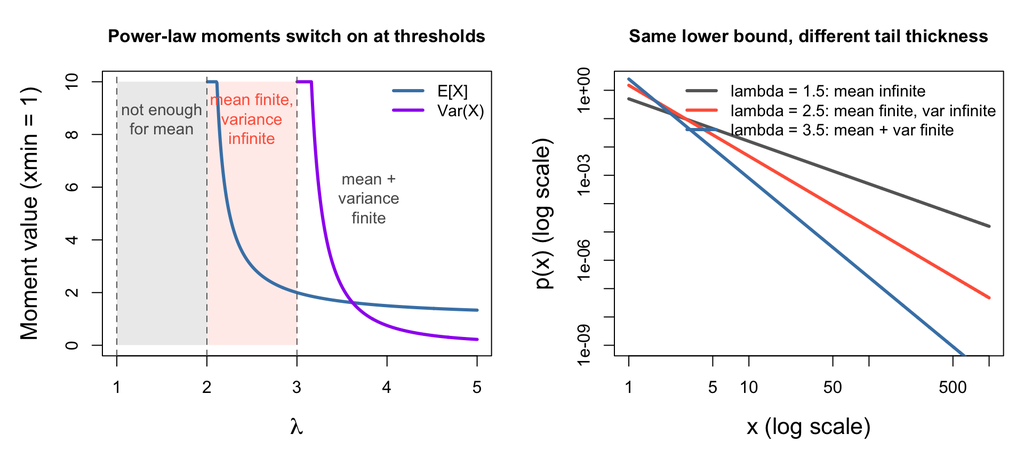

```r
## ── 幂指数门槛：归一化、均值、方差 ───────────────────────────

lam_grid <- seq(1.05, 5, length.out = 600)
xmin_thr <- 1
mean_thr <- ifelse(lam_grid > 2, (lam_grid - 1) / (lam_grid - 2) * xmin_thr, NA)
var_thr <- ifelse(lam_grid > 3,
                  (lam_grid - 1) * xmin_thr^2 /
                    ((lam_grid - 3) * (lam_grid - 2)^2),
                  NA)

par(mfrow = c(1, 2), mar = c(4.6, 5.0, 3.5, 1))

plot(NA, xlim = c(1, 5), ylim = c(0, 10),
     main = "Power-law moments switch on at thresholds",
     xlab = expression(lambda), ylab = "Moment value (xmin = 1)",
     cex.lab = 1.35, cex.main = 1.05)
rect(1, 0, 2, 10, col = adjustcolor("gray70", 0.25), border = NA)
rect(2, 0, 3, 10, col = adjustcolor("tomato", 0.12), border = NA)
lines(lam_grid, pmin(mean_thr, 10), col = "steelblue", lwd = 3)
lines(lam_grid, pmin(var_thr, 10), col = "purple", lwd = 3)
abline(v = c(1, 2, 3), col = "gray40", lty = 2)
text(1.5, 8.6, "not enough\nfor mean", col = "gray35", cex = 0.95)
text(2.5, 8.6, "mean finite,\nvariance\ninfinite", col = "tomato", cex = 0.95)
text(3.8, 5.6, "mean +\nvariance\nfinite", col = "gray35", cex = 0.95)
legend("topright", c("E[X]", "Var(X)"),
       col = c("steelblue", "purple"), lwd = 3, bty = "n", cex = 0.95)

x_tail <- seq(1, 1000, length.out = 2000)
plot(NA, xlim = c(1, 1000), ylim = c(1e-9, 2),
     log = "xy",
     main = "Same lower bound, different tail thickness",
     xlab = "x (log scale)", ylab = "p(x) (log scale)",
     cex.lab = 1.35, cex.main = 1.05)
lam_show <- c(1.5, 2.5, 3.5)
cols_show <- c("gray40", "tomato", "steelblue")
for (i in seq_along(lam_show)) {
  lam <- lam_show[i]
  lines(x_tail, (lam - 1) * x_tail^(-lam), col = cols_show[i], lwd = 3)
}
legend("topright",
       c("lambda = 1.5: mean infinite",
         "lambda = 2.5: mean finite, var infinite",
         "lambda = 3.5: mean + var finite"),
       col = cols_show, lwd = 3, bty = "n", cex = 0.95)
```

区间 $2<\lambda\le3$ 经常被单独讨论，因为它有一个很清楚的统计含义：**平均规模存在，但波动没有有限的理论尺度**。这时可以谈平均城市规模、平均财富、平均连接数；但方差不存在，样本波动会长期受少数极端大值支配。数据量增加时，新的超大观测仍可能显著改写方差估计。

另外两个区间也各有含义。$1<\lambda\le2$ 更重尾：总概率已经有限，但理论均值不存在，样本平均会非常不稳定。$\lambda>3$ 则温和得多：均值和方差都有限，虽然尾部仍比指数厚。实际数据还常有有限系统大小、测量下限、上限截断、机制混合，所以经验估计的 $\lambda$ 可以落在不同区间；关键不是记某个固定范围，而是读懂 $\lambda$ 所在区间对应的矩是否存在。

## 4.3 数值验证：固定 $E[\ln X]$ 时，幂律的熵最高

取 $x_{\min}=1$，固定 $E[\ln X]=0.5$。最大熵解应为 $\lambda = 1 + 1/0.5 = 3$ 的 Pareto 型幂律。下面把几个支撑同为 $[1,\infty)$、且数值上调到同一个 $E[\ln X]$ 的候选分布放在一起比较。

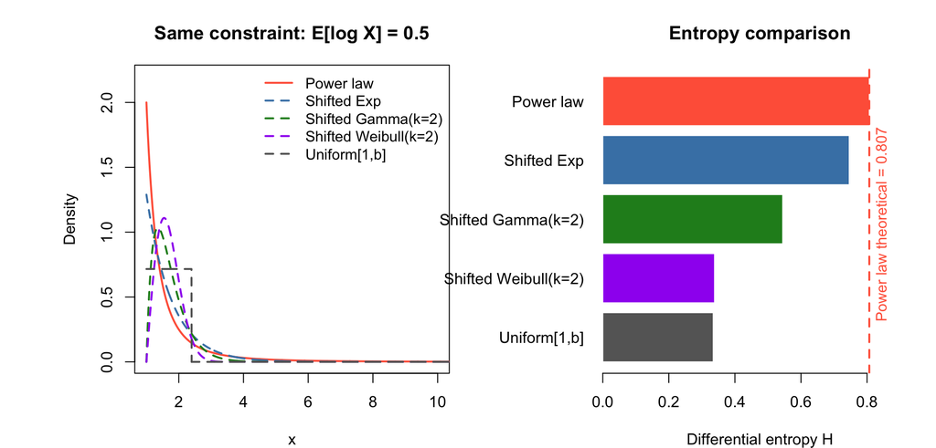

```r
## ── 固定 E[log X] 的候选分布熵比较 ───────────────────────────

xmin_pl <- 1
m_log   <- 0.5
lambda_pl <- 1 + 1 / (m_log - log(xmin_pl))

safe_entropy <- function(dfun, lower = xmin_pl, upper = Inf) {
  integrate(function(x) {
    p <- dfun(x)
    out <- numeric(length(p))
    keep <- p > 0
    out[keep] <- -p[keep] * log(p[keep])
    out
  }, lower = lower, upper = upper, rel.tol = 1e-9)$value
}

elog_shift_exp <- function(rate) {
  integrate(function(x) log(x) * rate * exp(-rate * (x - xmin_pl)),
            lower = xmin_pl, upper = Inf, rel.tol = 1e-9)$value
}
rate_shift_exp <- uniroot(function(r) elog_shift_exp(r) - m_log,
                          c(0.02, 20))$root

elog_shift_gamma <- function(rate, shape = 2) {
  integrate(function(x) log(x) * dgamma(x - xmin_pl, shape = shape, rate = rate),
            lower = xmin_pl, upper = Inf, rel.tol = 1e-9)$value
}
rate_shift_gamma <- uniroot(function(r) elog_shift_gamma(r) - m_log,
                            c(0.02, 20))$root

elog_shift_weibull <- function(scale, shape = 2) {
  integrate(function(x) log(x) * dweibull(x - xmin_pl, shape = shape, scale = scale),
            lower = xmin_pl, upper = Inf, rel.tol = 1e-9)$value
}
scale_shift_weib <- uniroot(function(s) elog_shift_weibull(s) - m_log,
                            c(0.05, 30))$root

elog_uniform <- function(b) (b * log(b) - b + xmin_pl) / (b - xmin_pl)
b_unif_pl <- uniroot(function(b) elog_uniform(b) - m_log, c(1.01, 20))$root

dists_pl <- list(
  "Power law" = function(x) (lambda_pl - 1) * xmin_pl^(lambda_pl - 1) * x^(-lambda_pl),
  "Shifted Exp" = function(x) rate_shift_exp * exp(-rate_shift_exp * (x - xmin_pl)),
  "Shifted Gamma(k=2)" = function(x) dgamma(x - xmin_pl, shape = 2, rate = rate_shift_gamma),
  "Shifted Weibull(k=2)" = function(x) dweibull(x - xmin_pl, shape = 2, scale = scale_shift_weib),
  "Uniform[1,b]" = function(x) dunif(x, xmin_pl, b_unif_pl)
)

ent_pl <- c(
  "Power law" = log(xmin_pl) - log(lambda_pl - 1) + 1 + 1 / (lambda_pl - 1),
  "Shifted Exp" = safe_entropy(dists_pl[["Shifted Exp"]]),
  "Shifted Gamma(k=2)" = safe_entropy(dists_pl[["Shifted Gamma(k=2)"]]),
  "Shifted Weibull(k=2)" = safe_entropy(dists_pl[["Shifted Weibull(k=2)"]]),
  "Uniform[1,b]" = log(b_unif_pl - xmin_pl)
)

elog_checks <- sapply(dists_pl, function(dfun) {
  integrate(function(x) log(x) * dfun(x),
            lower = xmin_pl, upper = Inf, rel.tol = 1e-8)$value
})

x_plot_pl <- seq(1, 12, length.out = 2000)
dist_cols_pl <- c("tomato", "steelblue", "forestgreen", "purple", "gray40")

par(mfrow = c(1, 2), mar = c(4, 7.2, 3.5, 1))

plot(NA, xlim = c(1, 10), ylim = c(0, 2.2),
     main = "Same constraint: E[log X] = 0.5",
     xlab = "x", ylab = "Density")
for (i in seq_along(dists_pl)) {
  lines(x_plot_pl, dists_pl[[i]](x_plot_pl), col = dist_cols_pl[i], lwd = 2,
        lty = ifelse(i == 1, 1, 2))
}
legend("topright", names(dists_pl), col = dist_cols_pl, lwd = 2,
       lty = c(1, rep(2, 4)), bty = "n", cex = 0.95)

barplot(rev(ent_pl), horiz = TRUE, col = rev(dist_cols_pl),
        border = "white", las = 1, xlim = c(0, max(ent_pl) * 1.18),
        main = "Entropy comparison",
        xlab = "Differential entropy H")
abline(v = ent_pl["Power law"], col = "tomato", lwd = 2, lty = 2)
text(ent_pl["Power law"] * 1.045, 3.0,
     paste("Power law theoretical =", round(ent_pl["Power law"], 3)),
     col = "tomato", adj = 0.5, srt = 90, cex = 0.95)
```

上面的每条候选分布都满足同一个约束；数值核验：

| distribution | E_log_X_numeric |
| --- | --- |
| Power law | 0.500000 |
| Shifted Exp | 0.500000 |
| Shifted Gamma(k=2) | 0.499999 |
| Shifted Weibull(k=2) | 0.500000 |
| Uniform[1,b] | 0.499998 |

**Power law 的红色条最长——在支撑 $[x_{\min},\infty)$ 和 $E[\ln X]$ 固定时，幂律分布确实熵最高。**

Uniform 看起来”平”，但它在 $x>b$ 处把概率硬截成 0，偷偷加入了”绝不会超过 $b$“的额外信息；shifted exponential / gamma / Weibull 则把尾部压得比幂律薄，也是在约束之外多说了话。幂律只固定几何尺度，不固定算术均值，所以它允许极端大值出现得比指数多得多。

## 4.4 严格证明：固定对数均值下，幂律熵最大

这一节是可跳过的严格证明（与指数分布那节的 Gibbs 论证同构）。只想要结论——“固定 $E[\ln X]$ 时幂律熵最大”——的话，可以直接跳到下一节《scale-free》。

用与指数分布完全同构的 Gibbs 不等式。对 $[x_{\min},\infty)$ 上任意满足 $E_p[\ln X]=m$ 的密度 $p$，取同约束的幂律候选

$$q(x) =
(\lambda-1)x_{\min}^{\lambda-1}x^{-\lambda},
\qquad
\lambda = 1 + \frac{1}{m-\ln x_{\min}}$$

KL 散度非负：

$$\begin{aligned}
0 \le \int p\ln\frac{p}{q}\,dx
&= -H(p) - \int p\ln q\,dx \\[2pt]
&= -H(p) - \int p\Bigl[\ln(\lambda-1)+(\lambda-1)\ln
x_{\min}-\lambda\ln x\Bigr]dx \\[2pt]
&= -H(p) -\ln(\lambda-1)-(\lambda-1)\ln x_{\min}+\lambda m \\[2pt]
&= -H(p) + \ln x_{\min} - \ln(\lambda-1) + 1 + \frac{1}{\lambda-1}
\end{aligned}$$

最后一行正是 $H(q)$，所以 $H(p)\le H(q)$，等号仅当 $p=q$。这就是”变分找出它，Gibbs 盖章”的同一套路：因为 $\ln q$ 对 $\ln x$ 线性，交叉熵只依赖固定的 $E[\ln X]$，不再依赖 $p$ 的其他细节。

## 4.5 幂律 = 对数尺度上的指数

这一节把”幂律”彻底还原成一句话：**它就是指数分布，只不过住在对数尺度上**。先从几何看见它，再一步换元坐实。

**几何入口：拉直它的坐标系，就读出它的约束。** 通解取对数，$p\propto e^{-\lambda f(x)}$ 两边取 $\ln$：

$$\ln p(x) = -\lambda\, f(x) +
\text{常数}$$

$\ln p$ 是 $f(x)$ 的**一次函数**。把纵轴取 $\ln p$、横轴取 $f(x)$，任何最大熵分布都是一条斜率 $-\lambda$ 的直线。反过来，**“哪种坐标系把分布拉直” = “它约束哪个 $f$” = “它是哪种最大熵分布”**——log-log、lin-log 不是随手挑的画法，是”把 $\ln p$ 对被约束量画出来”。

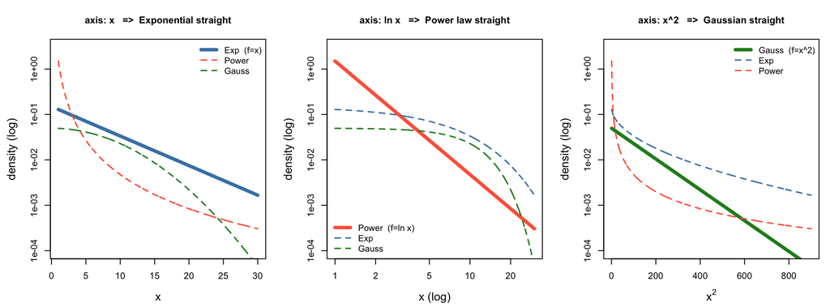

```r
## 每个最大熵分布只在"横轴 = 它的 f(x)"时是直线
x <- seq(1, 30, length.out = 1500)
p_exp   <- 0.15 * exp(-0.15 * x)                 # f = x
p_power <- (2.5 - 1) * x^(-2.5)                   # f = ln x, xmin = 1
p_gauss <- dnorm(x, 0, 8)                         # f = x^2 (mu = 0)
col_e <- "steelblue"; col_p <- "tomato"; col_g <- "forestgreen"
yl <- c(1e-4, 3)
par(mfrow = c(1, 3), mar = c(4.4, 4.6, 3.6, 1))

# A: 横轴 x → 指数直
plot(x, p_exp, type = "l", lwd = 4, col = col_e, log = "y", ylim = yl,
     main = "axis: x   =>  Exponential straight",
     xlab = "x", ylab = "density (log)", cex.lab = 1.25, cex.main = 1.05)
lines(x, p_power, col = col_p, lwd = 1.6, lty = 2)
lines(x, p_gauss, col = col_g, lwd = 1.6, lty = 2)
legend("topright", c("Exp  (f=x)", "Power", "Gauss"),
       col = c(col_e, col_p, col_g), lwd = c(4, 1.6, 1.6), lty = c(1, 2, 2),
       bty = "n", cex = 0.95)

# B: 横轴 ln x → 幂律直
plot(x, p_power, type = "l", lwd = 4, col = col_p, log = "xy", ylim = yl,
     main = "axis: ln x   =>  Power law straight",
     xlab = "x (log)", ylab = "density (log)", cex.lab = 1.25, cex.main = 1.05)
lines(x, p_exp, col = col_e, lwd = 1.6, lty = 2)
lines(x, p_gauss, col = col_g, lwd = 1.6, lty = 2)
legend("bottomleft", c("Power  (f=ln x)", "Exp", "Gauss"),
       col = c(col_p, col_e, col_g), lwd = c(4, 1.6, 1.6), lty = c(1, 2, 2),
       bty = "n", cex = 0.95)

# C: 横轴 x^2 → 高斯直
xx <- x^2
plot(xx, p_gauss, type = "l", lwd = 4, col = col_g, log = "y", ylim = yl,
     main = "axis: x^2   =>  Gaussian straight",
     xlab = expression(x^2), ylab = "density (log)", cex.lab = 1.25, cex.main = 1.05)
lines(xx, p_exp, col = col_e, lwd = 1.6, lty = 2)
lines(xx, p_power, col = col_p, lwd = 1.6, lty = 2)
legend("topright", c("Gauss  (f=x^2)", "Exp", "Power"),
       col = c(col_g, col_e, col_p), lwd = c(4, 1.6, 1.6), lty = c(1, 2, 2),
       bty = "n", cex = 0.95)
```

三张图同一批曲线，只换横轴：**每个分布只在”横轴 = 它自己的 $f$“那张里才笔直**。读成对照表：

| 分布 | 把它拉直的坐标（纵 $\ln p$，横 $\cdots$） | 斜率 | 约束 $f(x)$ |
| --- | --- | --- | --- |
| 指数 | $x$（lin-log） | $-\lambda$ | $x$ |
| 幂律 | $\ln x$（log-log） | $-\lambda$ | $\ln x$ |
| 正态 | $x^2$ | $-\tfrac{1}{2\sigma^2}$ | $x^2$ |

**点破：幂律的 log-log 直线，就是它在对数尺度上是指数。** 幂律在 log-log 上直，意思是 $\ln p$ 对 $\ln x$ 线性——而”$\ln p$ 对某个变量线性”正是**指数分布**在那个变量上的招牌（指数在 lin-log 上直）。所以幂律的 log-log 直线，等价于”把 $\ln x$ 当新变量后，它是一条 lin-log 直线 = 一个指数分布”。换元把它坐实：令 $Y=\ln(X/x_{\min})\ge 0$（$x=x_{\min}e^{y}$、$dx/dy=x$），

$$p_Y(y)\;\propto\;\bigl(x_{\min}e^{y}\bigr)^{-\lambda}\cdot
x_{\min}e^{y} = e^{-(\lambda-1)y}$$

**$Y=\ln(X/x_{\min})$ 恰好服从指数分布**，速率 $\lambda-1$：

$$\text{幂律}(x)\;\Longleftrightarrow\;\text{指数}(\ln
x)$$

“$\ln x$ 之于幂律 = $x$ 之于指数”。这也顺手解释了推导里的约束公式 $E[\ln X]=\ln x_{\min}+\tfrac{1}{\lambda-1}$——右边的 $\tfrac{1}{\lambda-1}$ 正是速率 $\lambda-1$ 的指数分布的均值。**约束几何均值 $\langle\ln x\rangle$，就是约束”对数空间里那个指数”的均值**，和指数约束 $\langle x\rangle$ 一模一样。所以幂律不是”另一种”指数，它就是指数，只是换了尺度。

由此，无记忆性的对仗也现形了：

|  | 指数分布 | 幂律分布 |
| --- | --- | --- |
| 无记忆形式 | $P(X>s{+}t\mid X>s)=P(X>t)$ | $P(X>ct\mid X>t)=P\!\left(\tfrac{X}{x_{\min}}>c\right)$ |
| 不变的操作 | **加**一个量 $t$（平移） | **乘**一个倍数 $c$（缩放） |
| 特征尺度 | 有，$1/\lambda$ | 无（scale-free） |

指数是**加性无记忆**（线性尺度上平移不变），幂律是**乘性无记忆**（对数尺度上平移不变 = 缩放不变）。取一次对数，乘性就变加性、幂律就变指数——**同一个”无记忆”，只是活在不同尺度上**。下一节把这个”乘性无记忆”画出来，并证明幂律是**唯一**的无标度分布。

## 4.6 Scale-free：把”乘性无记忆”画出来，并证明它唯一

上一节已得幂律是**乘性无记忆**——$P(X>ct\mid X>t)=c^{-(\lambda-1)}$，只看倍数 $c$、不看起点 $t$。这里做两件上节没做的事：把它画出来，并证明幂律是**唯一**这样的分布。

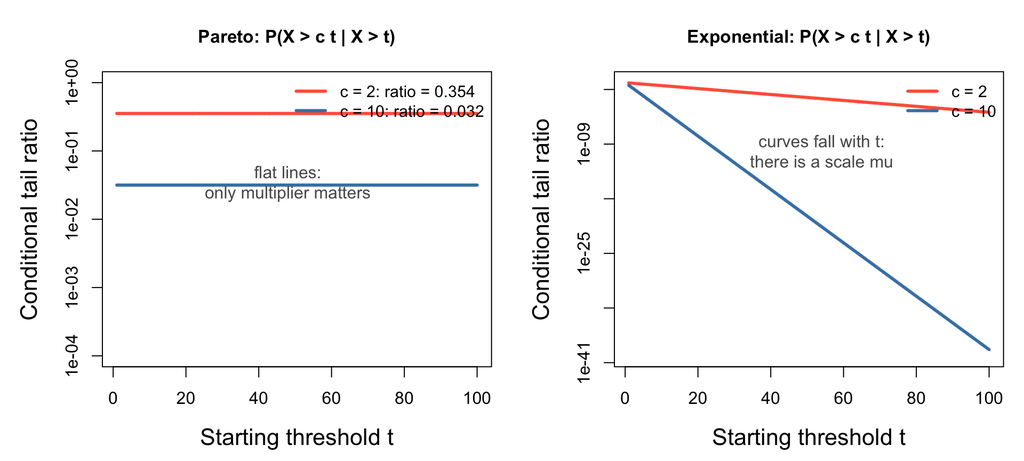

```r
## ── Scale-free: tail ratios depend on multiplier, not starting scale ─────

t_grid <- seq(1, 100, length.out = 600)
lambda_sf <- 2.5
mu_sf <- 10
multipliers <- c(2, 10)
cols_sf <- c("tomato", "steelblue")

par(mfrow = c(1, 2), mar = c(4.6, 5.0, 3.5, 1))

plot(NA, xlim = range(t_grid), ylim = c(1e-4, 1),
     log = "y",
     main = "Pareto: P(X > c t | X > t)",
     xlab = "Starting threshold t", ylab = "Conditional tail ratio",
     cex.lab = 1.35, cex.main = 1.05)
for (i in seq_along(multipliers)) {
  c_i <- multipliers[i]
  lines(t_grid, rep(c_i^(-(lambda_sf - 1)), length(t_grid)),
        col = cols_sf[i], lwd = 3)
}
legend("topright",
       paste0("c = ", multipliers, ": ratio = ",
              round(multipliers^(-(lambda_sf - 1)), 3)),
       col = cols_sf, lwd = 3, bty = "n", cex = 0.95)
text(48, 0.035, "flat lines:\nonly multiplier matters",
     col = "gray35", cex = 1.0)

plot(NA, xlim = range(t_grid), ylim = c(1e-40, 1),
     log = "y",
     main = "Exponential: P(X > c t | X > t)",
     xlab = "Starting threshold t", ylab = "Conditional tail ratio",
     cex.lab = 1.35, cex.main = 1.05)
for (i in seq_along(multipliers)) {
  c_i <- multipliers[i]
  lines(t_grid, exp(-(c_i - 1) * t_grid / mu_sf),
        col = cols_sf[i], lwd = 3)
}
legend("topright", paste0("c = ", multipliers),
       col = cols_sf, lwd = 3, bty = "n", cex = 0.95)
text(54, 1e-10, "curves fall with t:\nthere is a scale mu",
     col = "gray35", cex = 1.0)
```

左图的水平线就是无标度：对幂律，“再翻倍”的概率不随起点 $t$ 改变；右图指数则越往后再翻倍越难（$P(X>ct\mid X>t)=e^{-(c-1)t/\mu}$ 依赖 $t$）——这正是指数有特征尺度 $\mu$、幂律没有的根源。

**唯一性**：若一个足够规则的正函数对任意缩放都满足 $f(cx)=a(c)f(x)$，它只能是 $Kx^{-\lambda}$。所以”精确无标度”这一条本身就把分布钉死成幂律——**scale-free 不是幂律的一条性质，而是它的另一个定义**。（经验数据只在尾部或有限区间近似满足；截断幂律、对数正态在有限 log-log 图上也近似直，所以直线是线索、不是证明，严格判定见《怎样才算”真的”幂律》。）

## 4.7 无标度 = 分形 = 临界：同一枚硬币的三面

刚证的”精确无标度只能是幂律”，一脚就踏进了**分形几何**——因为”无标度”正是分形的定义。这一节把幂律、分形、临界动力学接成同一件事，也是全章通向复杂系统的出口。

**自相似 ⟺ 尺度不变 ⟺ 幂律。** 分形的定义性质是**自相似**：放大任意倍数看起来一样。“缩放后形状不变”就是 $f(cx)=a(c)f(x)$——正是上面唯一性定理的前提，而结论是它只能是 $x^{-\lambda}$。所以这三句话是同一个命题的三种说法：分形自相似、尺度不变、幂律。

**分形维数就是一个幂指数。** 怎么测一个分形？用边长 $\varepsilon$ 的盒子盖住它、数盒子数 $N(\varepsilon)$，分形满足 $N(\varepsilon)\propto\varepsilon^{-D}$——一条幂律，指数 $D$ 就是**分形维数**。测分形 = 在 log-log 上量斜率（还是上一节那套）：

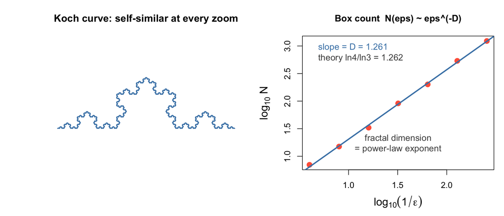

```r
## Koch 曲线 + 盒计数：分形维数 D 就是一条 log-log 幂律的斜率
koch_points <- function(level) {
  pts <- rbind(c(0,0), c(1,0))
  ang <- pi/3
  R <- matrix(c(cos(ang), sin(ang), -sin(ang), cos(ang)), 2, 2)
  for (it in seq_len(level)) {
    new <- pts[1, , drop=FALSE]
    for (i in 1:(nrow(pts)-1)) {
      A <- pts[i,]; B <- pts[i+1,]
      d <- (B - A)/3
      P1 <- A + d; P3 <- A + 2*d
      peak <- P1 + as.numeric(R %*% d)
      new <- rbind(new, P1, peak, P3, B)
    }
    pts <- new
  }
  pts
}
P <- koch_points(6)
dens <- do.call(rbind, lapply(1:(nrow(P)-1), function(i){
  A<-P[i,]; B<-P[i+1,]; t<-seq(0,1,length.out=6)
  cbind(A[1]+(B[1]-A[1])*t, A[2]+(B[2]-A[2])*t)
}))
boxcount <- function(pts, eps) nrow(unique(cbind(floor(pts[,1]/eps), floor(pts[,2]/eps))))
eps <- 1/2^(2:8)
Nbox <- sapply(eps, function(e) boxcount(dens, e))
D_box <- coef(lm(log(Nbox) ~ log(1/eps)))[2]

par(mfrow = c(1, 2), mar = c(4.6, 5.0, 3.6, 1))
plot(P, type = "l", asp = 1, col = "steelblue", lwd = 1.5, axes = FALSE,
     xlab = "", ylab = "", main = "Koch curve: self-similar at every zoom")
plot(log10(1/eps), log10(Nbox), pch = 16, col = "tomato", cex = 1.5,
     main = "Box count  N(eps) ~ eps^(-D)",
     xlab = expression(log[10](1/epsilon)), ylab = expression(log[10]~N),
     cex.lab = 1.3, cex.main = 1.1)
abline(lm(log10(Nbox) ~ log10(1/eps)), col = "steelblue", lwd = 2.5)
legend("topleft",
       c(sprintf("slope = D = %.3f", D_box), sprintf("theory ln4/ln3 = %.3f", log(4)/log(3))),
       bty = "n", cex = 1.05, text.col = c("steelblue","gray30"))
text(mean(log10(1/eps)), min(log10(Nbox))+0.4,
     "fractal dimension\n= power-law exponent", col = "gray30", cex = 1.05)
```

Koch 曲线盒计数的斜率给出 $D=\ln4/\ln3\approx1.26$——**非整数维**，正是幂指数的化身。Cantor 集 $\ln2/\ln3\approx0.63$、Sierpinski $\ln3/\ln2\approx1.58$、海岸线 $L(\varepsilon)\propto\varepsilon^{1-D}$（量得越细越长）同理。所以幂律的指数 $\lambda$ 和分形维数 $D$ 是**同一类东西**——“某个量随尺度怎么标度”的指数。

**动力学来路：混沌、SOC、临界。** 幂律/分形在自然界满地都是，因为好几类动力学天然收敛到尺度不变：确定性**混沌**落在分形维的奇怪吸引子上（Lorenz、Hénon）；**自组织临界**（Bak–Tang–Wiesenfeld 沙堆）让耗散系统自动停在临界点、雪崩大小服从幂律，不用调参——地震（Gutenberg–Richter，就是前面表里那条）、森林火灾、神经雪崩都属此类；**相变临界点**上关联长度发散、没有特征尺度、关联按幂律衰减，重整化群（RG）把系统看成**缩放变换的不动点**，这是”尺度不变 $\Rightarrow$ 幂律”最深的理论。

**焊接（最漂亮的一处）。** 本章给过幂律一条最大熵来路：在尺度不变测度 $dx/x$ 下”什么都不知道”（见后面延伸章）。而 $dx/x$ 正是唯一在 $x\to cx$ 下不变的测度——它**就是** RG／分形语言里的”尺度不变”。于是

$$\underbrace{\text{最大熵：对数尺度上最无知}}_{\text{推断语言}}\;=\;\underbrace{\text{RG：缩放变换的不动点}}_{\text{动力学语言}}$$

两种语言，同一个”没有特征尺度”。上面那条唯一性定理是它的**静态影子**，RG 是它的**动力学版本**。

**给生物的一条线索。** 分形/无标度在生物学里是结构性的：血管、支气管、神经树都有分枝网络；West–Brown–Enquist 曾从空间填充的分枝输送网络推导出 $3/4$ 代谢标度，神经雪崩则促成了”临界脑”假说。(West et al. 1997; Beggs and Plenz 2003) 这些是有力的机制线索，而不是“所有生命系统都处在临界点”的定理。

## 4.8 合体：同时约束 $\langle x\rangle$ 和 $\langle\ln x\rangle$ → Gamma

指数只固定算术均值 $\langle x\rangle$，幂律只固定几何均值 $\langle\ln x\rangle$。两个**同时**固定呢？两个约束配两个乘子 $\lambda_1$（配 $x$）、$\lambda_2$（配 $\ln x$），代入通解：

$$p(x)\propto e^{-\lambda_1 x -
\lambda_2\ln x} = x^{-\lambda_2}\,e^{-\lambda_1 x}$$

**幂律核 $\times$ 指数尾**。在 $(0,\infty)$ 上这正是 **Gamma 分布**（形状 $k=1-\lambda_2$、速率 $\lambda_1$）；在 $[x_{\min},\infty)$ 上就是文献里的”带指数截断的幂律”。两个旋钮，两个极限：

- $\lambda_1\to 0$（松开算术均值）→ 指数尾消失 → **纯幂律** $x^{-\lambda_2}$；
- $\lambda_2\to 0$（松开几何均值）→ 幂律核消失 → **纯指数** $e^{-\lambda_1 x}$。

所以**指数和幂律不是两个物种，是同一个族的两端**：$\lambda_2$ 管小-中尺度的幂律核（log-log 斜率 $-\lambda_2$），$\lambda_1$ 管大尺度的指数截断（在 $x\sim 1/\lambda_1$ 处把尾巴掰下来）。下面两节的细胞谱系次临界情形、财富的 Kesten 稳态，尾部都恰好是这个”核 + 截断”形——它们不是巧合地”像” Gamma，而**就是**两个约束下的最大熵解。这也是”双约束”的第一次登场：下一章正态把约束换成 $x$ 和 $x^2$，同样两个乘子。

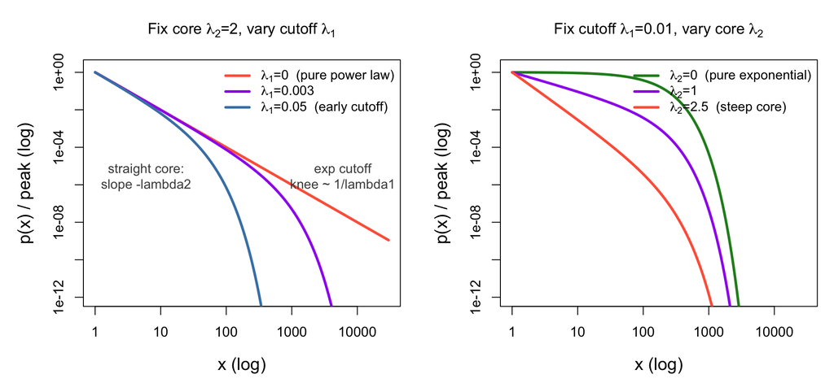

```r
## Gamma 桥：p ∝ x^{-λ2} e^{-λ1 x}。两个旋钮：λ1=指数尾截断，λ2=幂律核斜率
xg <- exp(seq(log(1), log(3e4), length.out = 1500))
dens <- function(x, l2, l1) x^(-l2) * exp(-l1 * x)
norm_plot <- function(x, l2, l1) { y <- dens(x, l2, l1); y / max(y) }

par(mfrow = c(1, 2), mar = c(4.6, 5.0, 3.6, 1))

# 左：固定核 λ2=2，变截断 λ1
l1s <- c(0, 0.003, 0.05); colsL <- c("tomato", "purple", "steelblue")
plot(NA, xlim = c(1, 3e4), ylim = c(1e-12, 1.5), log = "xy",
     main = expression("Fix core "*lambda[2]*"=2, vary cutoff "*lambda[1]),
     xlab = "x (log)", ylab = "p(x) / peak (log)", cex.lab = 1.25, cex.main = 1.1)
for (i in seq_along(l1s)) lines(xg, norm_plot(xg, 2, l1s[i]), col = colsL[i], lwd = 3)
legend("topright",
       c(expression(lambda[1]*"=0  (pure power law)"),
         expression(lambda[1]*"=0.003"),
         expression(lambda[1]*"=0.05  (early cutoff)")),
       col = colsL, lwd = 3, bty = "n", cex = 0.95)
text(6, 3e-6, "straight core:\nslope -lambda2", col = "gray30", cex = 0.95)
text(6000, 3e-6, "exp cutoff\nknee ~ 1/lambda1", col = "gray30", cex = 0.95)

# 右：固定截断 λ1=0.01，变核 λ2；λ2=0 = 纯指数
l2s <- c(0, 1, 2.5); colsR <- c("forestgreen", "purple", "tomato")
plot(NA, xlim = c(1, 3e4), ylim = c(1e-12, 1.5), log = "xy",
     main = expression("Fix cutoff "*lambda[1]*"=0.01, vary core "*lambda[2]),
     xlab = "x (log)", ylab = "p(x) / peak (log)", cex.lab = 1.25, cex.main = 1.1)
for (i in seq_along(l2s)) lines(xg, norm_plot(xg, l2s[i], 0.01), col = colsR[i], lwd = 3)
legend("topright",
       c(expression(lambda[2]*"=0  (pure exponential)"),
         expression(lambda[2]*"=1"),
         expression(lambda[2]*"=2.5  (steep core)")),
       col = colsR, lwd = 3, bty = "n", cex = 0.95)
```

左图：固定核 $\lambda_2$、增大 $\lambda_1$，指数截断的”膝盖”从右往左移，$\lambda_1=0$ 时退回一条笔直的纯幂律。右图：固定截断 $\lambda_1$、增大核 $\lambda_2$，log-log 上的核越来越陡，$\lambda_2=0$ 时退回纯指数。现实里”有限尺寸截断的幂律”几乎都活在这张图内部。

## 4.9 现实里的幂指数落在哪

前面都是框架，这里落地。一些被反复研究的幂律，按**尾指数 $\alpha$**（生存函数 $P(X>x)\propto x^{-\alpha}$，即密度指数 $\lambda-1$）列出——落在哪个矩区间（区间含义见前面《幂指数的三个门槛》），直接决定”平均、方差还有没有意义”：

[output not shown]

**一句话提醒**：这些指数都是**经验估计、区间近似**。严格统计检验表明，很多被称作”幂律”的数据在整段上并不是干净幂律，而是**截断幂律、对数正态或混合**。(Clauset et al. 2009) 所以看到 log-log 近似直线，是**线索**，值得追问机制；不是终点。这个”线索不是证明”到底有多大坑，下一节展开。

## 4.10 怎样才算”真的”幂律：拟合、检验与陷阱

如果你要对真实数据（基因表达尾、网络度数……）判断是不是幂律，这一节是必读；只想懂原理的话可以跳到《现实案例》。核心参考是 Clauset、Shalizi、Newman 的方法论综述。(Clauset et al. 2009)

**两个常见做法都是错的。** 早期大量”幂律”论文只靠：(1) 把数据画在 log-log 上、肉眼看直线；(2) 对 log-log 直方图做最小二乘线性回归、报一个高 $R^2$。两条都不成立：

- log-log 回归的斜率估计**有偏**——分箱假象、尾部箱子噪声大、最小二乘的误差假设在对数空间根本不成立；
- **高 $R^2$ 证明不了幂律**——对数正态、指数、拉伸指数在有限区间的 log-log 上都能”看着挺直”。眼球更不是检验。

**正确的四步配方**（现在的金标准）：

1. **先定下限 $x_{\min}$**：幂律通常只在尾部成立。对每个候选 $x_{\min}$，用 Kolmogorov–Smirnov 距离（数据 vs 拟合幂律）最小化来选它。
2. **用最大似然估 $\lambda$，不用回归**。连续情形就是 Hill 估计量 $\hat\lambda = 1 + n\big/\sum_i \ln\frac{x_i}{x_{\min}}$，相合无偏；回归有偏。
3. **拟合优度检验**：算 KS 统计量，再用自助重采样得 $p$ 值。$p$ 小 → **拒绝**幂律假设。（$p$ 大只是”没拒绝”，不等于”证明是幂律”。）
4. **模型比较**：用似然比检验把幂律和**对数正态、指数、拉伸指数、带指数截断的幂律**对打。真问题不是”是不是幂律”，而是”幂律比这些替代品更好吗”。

**结论很扎心。** Clauset 等把 24 个前人称作幂律的真实数据集重估了一遍：干净通过的只有少数；很多和**对数正态无法区分**，或**带指数截断的幂律**拟合更好。后续 Broido 与 Clauset 重审约一千个网络，题目直接是《Scale-free networks are rare》。(Clauset et al. 2009; Broido and Clauset 2019)

**是、还是不是？对照才有意思。** 同样”看着重尾”，有的是幂律，有的根本不是——而判据回到**过程**（本章一直在讲的那条轴）：

| 现象 | 常被说成 | 更站得住的 | 生成过程 |
| --- | --- | --- | --- |
| 词频（Zipf）、地震能量 | 幂律 | 幂律（支持较强） | 临界 / 优先增长 |
| 财富、收入的**主体** | 幂律 | **对数正态**（仅极上尾近 Pareto） | 乘性增长，无托底 |
| 多数网络度分布 | 无标度幂律 | 常带截断或对数正态；纯无标度罕见 | —（Broido–Clauset 2019） |
| 身高、体重、测量误差 | —— | **高斯** | 加性平均 → CLT |
| 放射性寿命、无记忆等待 | —— | **指数** | 恒定风险率 |

四种过程，四种命运：**加**很多小量 → 高斯；**无记忆等待** → 指数；**乘**很多小量、没有下界托底 → 对数正态；乘性 + **reset/托底**（Kesten）或**临界/优先连接** → 真幂律。所以”是不是幂律”这个经验问题，本质是”背后是哪种过程”。**重尾 $\ne$ 幂律**：对数正态同样重尾，却来自完全不同的机制，在有限数据上还常和幂律难分——这正是 Clauset 检验要拆开的核心，也是为什么”看到直线要追问机制、而不是宣布胜利”。

这不是说”幂律不存在”，而是：**证据要用 MLE + 拟合优度 + 模型比较,并老实承认替代分布常常拟合得一样好、甚至更好**。注意它点名的两个头号劲敌——**对数正态**和**带指数截断的幂律**——正是本章已经出现过的两位：前者来自乘性过程 + CLT（《旁例：财富》），后者就是 Gamma 桥的内部。换句话说，“到底是幂律还是它俩”这个经验难题，本章的最大熵框架早已把三者摆在同一张谱系图上。实操工具：R 的 `poweRlaw` 包、Python 的 `powerlaw` 包都实现了上面这套配方。

上面那张过程表是”总”。接下来《现实案例》把其中**两行做实**——**临界分枝**（产出真幂律 $T^{-3/2}$）与**乘性 + 托底的 Kesten 过程**（主体对数正态、上尾 Pareto、常带截断）——看具体机制怎样产出幂律，也顺便看清那两个”劲敌”是怎么从同一批机制里冒出来的。

## 4.11 现实案例：细胞谱系的临界分枝怎样给出幂律尾部

这是上一节过程分类表里的**第一行**（临界 / 分枝）做实：幂律不只能由”只知道几何尺度”的最大熵推出，也能从一个具体的细胞分裂机制里长出来。本节结论一句话：**恰好临界（分裂=终止）的分枝过程，累计产出服从 $T^{-3/2}$ 幂律；稍微偏离临界，尾部就被指数截断**（这就落进了 Gamma 桥的”幂律核 + 指数尾”）。这是 Galton–Watson 分枝过程的经典结果。(Harris 1963) 想看这个结论怎么从组合数精确算出来，往下读；只要记住这句话的话，可以跳到《旁例：财富》。

考虑一个刻意简化的细胞谱系模型：从一个创始细胞开始，每个细胞独立地以概率 $q$ 分裂成两个子细胞，以概率 $1-q$ 终止（可理解为死亡或终末分化）；两个子细胞再重复同一规则。

这里研究的不是某个时刻的克隆大小，而是**直到谱系终止为止，累计出现过的总细胞数** $T$，创始细胞也算一个。若发生 $n$ 次分裂，谱系恰有 $n+1$ 次终止，因而 $T=2n+1$。满足这一条件的二叉谱系形状有第 $n$ 个 Catalan 数

$$C_n=\frac{1}{n+1}\binom{2n}{n}$$

种；每一种形状有同样的概率。因此

$$P(T=2n+1)=C_nq^n(1-q)^{n+1}.$$

Catalan 数在这里并不神秘：它数的是“分裂产生的活细胞从未先于终止事件耗尽”的所有合法谱系树。这个封闭形式让我们能直接看见临界点发生了什么。

当 $q=1/2$，分裂与终止恰好平衡，是**临界分枝**。用 $C_n\sim4^n/(\sqrt{\pi}n^{3/2})$，有

$$P(T=2n+1)=C_n2^{-(2n+1)}
\sim \sqrt{\frac{2}{\pi}}\,T^{-3/2}.$$

所以这个离散机制产生了幂指数 $3/2$ 的渐近尾部。它落在前面的 $1<\lambda\le2$ 区间：理想的、无限持续的临界模型中，$E[T]$ 不存在。不是说一片真实组织会产生无限多细胞，而是说极少数极长谱系足以让理论平均值失去稳定尺度。

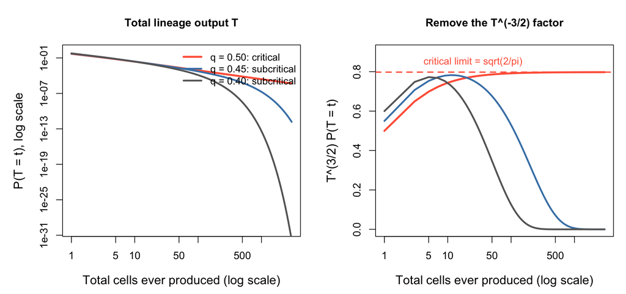

```r
## ── 细胞谱系：临界分枝给出幂律，偏离临界即出现截断 ─────────

n_branch <- 0:1500
t_branch <- 2 * n_branch + 1
q_branch <- c(0.50, 0.45, 0.40)
cols_branch <- c("tomato", "steelblue", "gray40")

log_p_total <- function(n, q) {
  lchoose(2 * n, n) - log(n + 1) + n * log(q) + (n + 1) * log1p(-q)
}
p_branch <- sapply(q_branch, function(q) exp(log_p_total(n_branch, q)))

par(mfrow = c(1, 2), mar = c(4.6, 5.0, 3.6, 1))

plot(t_branch, p_branch[, 1], type = "l", log = "xy", col = cols_branch[1], lwd = 3,
     xlim = c(1, max(t_branch)), ylim = c(1e-30, 1),
     main = "Total lineage output T",
     xlab = "Total cells ever produced (log scale)",
     ylab = "P(T = t), log scale",
     cex.lab = 1.18, cex.main = 1.05)
for (i in 2:length(q_branch)) {
  lines(t_branch, p_branch[, i], col = cols_branch[i], lwd = 2.7)
}
legend("topright", c("q = 0.50: critical", "q = 0.45: subcritical", "q = 0.40: subcritical"),
       col = cols_branch, lwd = c(3, 2.7, 2.7), bty = "n", cex = 0.95)

scaled_p <- sweep(p_branch, 1, t_branch^(3/2), "*")
plot(t_branch, scaled_p[, 1], type = "l", log = "x", col = cols_branch[1], lwd = 3,
     xlim = c(1, max(t_branch)), ylim = c(0, 0.9),
     main = "Remove the T^(-3/2) factor",
     xlab = "Total cells ever produced (log scale)",
     ylab = "T^(3/2) P(T = t)",
     cex.lab = 1.18, cex.main = 1.05)
for (i in 2:length(q_branch)) {
  lines(t_branch, scaled_p[, i], col = cols_branch[i], lwd = 2.7)
}
abline(h = sqrt(2 / pi), col = "tomato", lty = 2, lwd = 2)
text(25, 0.85, "critical limit = sqrt(2/pi)", col = "tomato", cex = 0.95)
```

左图中，$q=1/2$ 的红线在 log-log 坐标下趋近直线；$q=0.45$ 或 $0.40$ 时，尾部向下弯。右图把 $T^{-3/2}$ 这一幂律因子除掉：临界曲线趋向常数 $\sqrt{2/\pi}$，而两条次临界曲线继续掉到 0。这不是肉眼拟合，而是上面 Catalan 公式的精确计算。

更精确地，$q<1/2$ 时

$$P(T=t)\asymp t^{-3/2}\exp\left[-\frac{t}{2}\log\frac{1}{4q(1-q)}\right].$$

也就是“幂律核 $\times$ 指数截断”。$q$ 离 $1/2$ 越远，截断越早出现；若 $q>1/2$，则有正概率永不终止，$T$ 不再是一个只取有限值的概率分布。真实组织还会受到空间、资源、发育时间窗口和调控反馈的限制，因此即使局部接近临界，观测到的尾部也会被进一步截断。

这个案例与前文的最大熵推导回答的不是同一个问题。前文的连续 Pareto 是：在 $[x_{\min},\infty)$ 上只固定 $E[\ln X]$ 时，最少额外假设的分布；这里是：给定一个细胞分裂/终止的微观规则，累计谱系产出会怎样。前者给出**推断原则**，后者给出一种产生近似幂律的**细胞机制**。两者并不互相替代。

### 4.11.1 旁例：财富分布为什么常被谈幂律？

这是过程分类表的**第二、三行**做实（乘性增长、以及乘性 + 托底）。财富是个很有用的对照，恰好纠正一句常见错话：**“乘法增长必然产生幂律”并不对。** 若只有比例增长

$$W_{t+1}=A_tW_t,$$

那么 $\ln W_t=\ln W_0+\sum_{s<t}\ln A_s$；许多小的独立增长率相加时，中心极限定理首先指向的是**对数正态**，而不是幂律。

产生 Pareto 尾的一类经典机制是在比例增长之外持续加入收入、最低保障或重新进入：

$$W_{t+1}=A_tW_t+B_t,\qquad B_t>0.$$

在适当条件下（例如 $E[\ln A]<0$ 使总体过程有稳态，但仍有一部分时期 $A>1$），这个 Kesten 型递推的上尾满足

$$P(W>w)\sim w^{-\alpha},
\qquad E[A^\alpha]=1,$$

其中 $\alpha$ 是**尾/生存指数**（对应前面记号约定的 $\lambda-1$，即密度指数 $\lambda=\alpha+1$）。直觉上，$B_t$ 不让财富掉到零，偶尔连续的正增长又能把少数轨迹推得很高；两者共同形成”主体有尺度、上尾近似无尺度”的稳态。(Kesten 1973; Gabaix 2009)

所以财富数据里常见的不是一条从底到顶的纯幂律，而可能是主体近似对数正态、较高阈值以上才接近 Pareto 尾；税收、破产、有限寿命和财富上限都会让尾部弯下去。它与细胞谱系例子共同说明：幂律不是一个万能标签，而是由具体机制、观察尺度和截断条件共同决定的尾部描述。

# 5 正态分布 = 最大熵 + 均值 + 方差约束

## 5.1 推导

约束：$E[X] = \mu$，$\text{Var}(X) = \sigma^2$。需要两个约束函数 $f_1(x) = x$ 和 $f_2(x) = x^2$，代入通解：

$$p(x) = \frac{1}{Z}\, e^{-\lambda_1 x -
\lambda_2 x^2}$$

**配方**：指数里是 $x$ 的二次式，对它配方（把一次项凑进平方），常数项并入 $Z$：

$$-\lambda_1 x - \lambda_2 x^2 =
-\lambda_2\Bigl(x + \tfrac{\lambda_1}{2\lambda_2}\Bigr)^2 +
\underbrace{\tfrac{\lambda_1^2}{4\lambda_2}}_{\text{并入
}Z}$$

于是 $p(x) \propto e^{-\lambda_2 (x - \mu)^2}$，是中心在 $\mu = -\tfrac{\lambda_1}{2\lambda_2}$、方差 $\tfrac{1}{2\lambda_2}$ 的高斯。对照约束得 $\lambda_2 = \tfrac{1}{2\sigma^2}$、$\lambda_1 = -\tfrac{\mu}{\sigma^2}$，归一化常数 $Z = \sqrt{2\pi\sigma^2}$：

$$p(x) = \frac{1}{\sqrt{2\pi\sigma^2}}\,
e^{-(x - \mu)^2 / (2\sigma^2)}$$

微分熵 $H = -\int p\ln p\,dx$（步骤与 3.1 同构，只是把”均值”换成”方差”）：

$$\begin{aligned}
H &= -\int p\,\ln p\,dx \\[2pt]
&= -\int p\Bigl(-\tfrac12\ln(2\pi\sigma^2) -
\tfrac{(x-\mu)^2}{2\sigma^2}\Bigr)dx
&& \ln p = -\tfrac12\ln(2\pi\sigma^2) -
\tfrac{(x-\mu)^2}{2\sigma^2} \\[2pt]
&= \tfrac12\ln(2\pi\sigma^2)\!\int p\,dx +
\tfrac{1}{2\sigma^2}\!\int (x-\mu)^2 p\,dx
&& \text{拆开} \\[2pt]
&= \tfrac12\ln(2\pi\sigma^2)\cdot 1 +
\tfrac{1}{2\sigma^2}\cdot\sigma^2
&& \textstyle\int p\,dx = 1,\ \int (x-\mu)^2 p\,dx = \sigma^2
\\[2pt]
&= \tfrac12\ln(2\pi\sigma^2) + \tfrac12 = \tfrac12\ln(2\pi
e\,\sigma^2)
&& \tfrac12 = \tfrac12\ln e
\end{aligned}$$

即 $H[\text{Normal}(\mu,\sigma^2)] = \tfrac12\ln(2\pi e\,\sigma^2)$。注意它只依赖 $\sigma^2$、与 $\mu$ 无关——平移分布不改变展开程度。

**自行观看（拓展）。** [Why π is in the normal distribution (beyond integral tricks)](https://www.youtube.com/watch?v=cy8r7WSuT1I)（3Blue1Brown）专门解释上面归一化常数里的 $\pi$ 从何而来；适合在接受高斯形式之后观看。

## 5.2 数值验证：候选分布中，正态的熵最高

在 $\mu = 0$，$\sigma^2 = 1$ 的所有分布中比较熵：

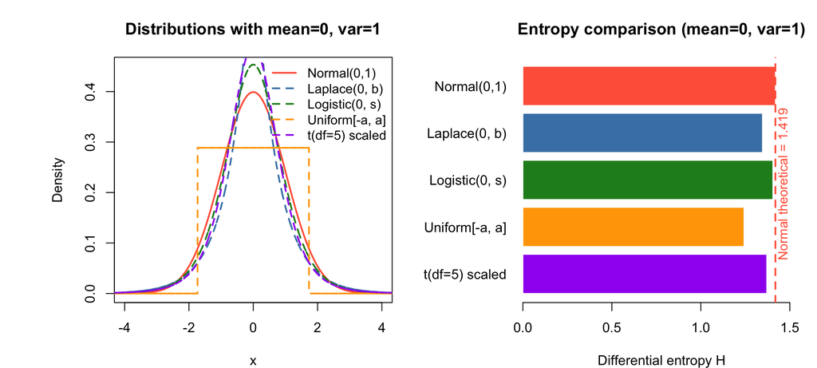

```r
x_full <- seq(-8, 8, length.out = 8000)
dx_f   <- diff(x_full)[1]

h_full <- function(p_vals) {
  p_vals <- pmax(p_vals, 1e-300)
  p_norm <- p_vals / (sum(p_vals) * dx_f)
  -sum(p_norm * log(p_norm)) * dx_f
}

# 均值 = 0，方差 = 1 的各种分布
sigma_target <- 1

# Laplace: Var = 2b^2, so b = 1/sqrt(2)
b_lap <- 1 / sqrt(2)
# Logistic: Var = pi^2 * s^2 / 3, so s = sqrt(3)/pi
s_log <- sqrt(3) / pi
# Uniform: Var = (2a)^2/12, so a = sqrt(3)
a_unif <- sqrt(3)

dists_n <- list(
  "Normal(0,1)"    = dnorm(x_full, 0, sigma_target),
  "Laplace(0, b)"  = 0.5/b_lap * exp(-abs(x_full)/b_lap),
  "Logistic(0, s)" = dlogis(x_full, 0, s_log),
  "Uniform[-a, a]" = dunif(x_full, -a_unif, a_unif),
  "t(df=5) scaled" = dt(x_full * sqrt(5/3), df = 5) * sqrt(5/3)
)

ent_n    <- sapply(dists_n, h_full)
h_theory_n <- 0.5 * log(2 * pi * exp(1))

par(mfrow = c(1, 2), mar = c(4, 7, 3.5, 1))

plot(NA, xlim = c(-4, 4), ylim = c(0, 0.45),
     main = "Distributions with mean=0, var=1",
     xlab = "x", ylab = "Density")
dist_cols_n <- c("tomato", "steelblue", "forestgreen", "orange", "purple")
for (i in seq_along(dists_n)) {
  lines(x_full, dists_n[[i]], col = dist_cols_n[i], lwd = 2,
        lty = ifelse(i == 1, 1, 2))
}
legend("topright", names(dists_n), col = dist_cols_n, lwd = 2,
       lty = c(1, rep(2, 4)), bty = "n", cex = 0.95)

barplot(rev(ent_n), horiz = TRUE, col = rev(dist_cols_n),
        border = "white", las = 1, xlim = c(0, max(ent_n) * 1.1),
        main = "Entropy comparison (mean=0, var=1)",
        xlab = "Differential entropy H")
abline(v = h_theory_n, col = "tomato", lwd = 2, lty = 2)
text(h_theory_n * 1.03, 3.0, paste("Normal theoretical =", round(h_theory_n, 3)),
     col = "tomato", adj = 0.5, srt = 90, cex = 0.95)
```

**Normal 的红色条最长——在均值和方差都固定时，正态分布的熵确实最大。**

## 5.3 CLT：另一条路到同一个终点

中心极限定理说的是：无论原始分布是什么，大量独立样本的均值趋向正态。

**自行观看。** [But what is the Central Limit Theorem?](https://www.youtube.com/watch?v=zeJD6dqJ5lo)（3Blue1Brown）以动画展示“不同形状为什么会在求和后趋同”；可先看视频再读下面的模拟图，也可读完后对照。

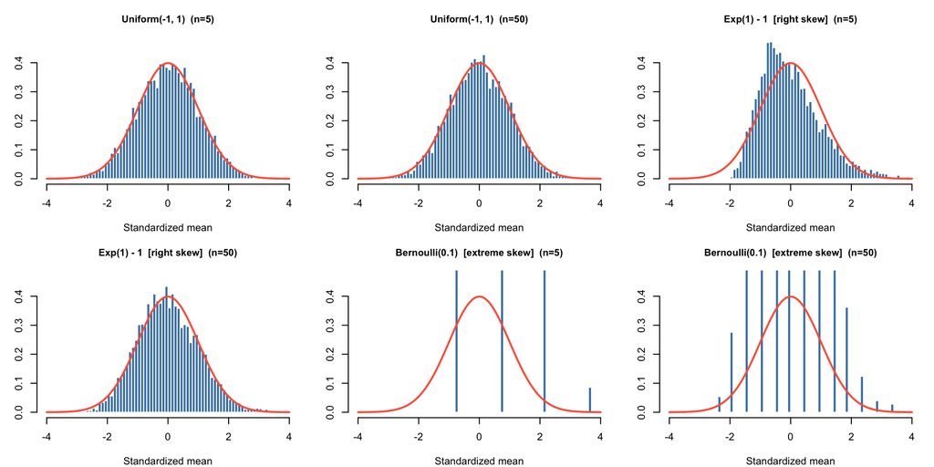

```r
n_sim <- 5000

par(mfrow = c(2, 3), mar = c(4, 3, 3, 1))

for (gen_info in list(
  list(gen = function(n) runif(n, -1, 1),       name = "Uniform(-1, 1)"),
  list(gen = function(n) rexp(n) - 1,            name = "Exp(1) - 1  [right skew]"),
  list(gen = function(n) rbinom(n,1,0.1) - 0.1,  name = "Bernoulli(0.1)  [extreme skew]")
)) {
  for (n_avg in c(5, 50)) {
    mat <- matrix(gen_info$gen(n_sim * n_avg), nrow = n_sim, ncol = n_avg)
    z   <- scale(rowMeans(mat))
    hist(z, breaks = 55, freq = FALSE, col = "steelblue", border = "white",
         main = paste0(gen_info$name, "  (n=", n_avg, ")"),
         xlab = "Standardized mean", xlim = c(-4, 4), ylim = c(0, 0.47),
         cex.main = 0.95)
    curve(dnorm(x), add = TRUE, col = "tomato", lwd = 2)
  }
}
```

**CLT 和最大熵是到达正态分布的两条独立道路**：

- CLT 说：加法的极限是正态（数学事实）
- 最大熵说：在固定均值和方差下，最无偏见的分布是正态（逻辑原则）

它们的结论一致，但逻辑完全独立。CLT 不需要熵的概念，最大熵不需要求和的概念。

下面用傅里叶变换给出 CLT 的证明。只想要结论的话，可以直接跳到下一节《物理实例》。

### 5.3.1 细节：用傅里叶变换证明 CLT

**思路。** 上一段说过：独立随机变量相加，密度做**卷积**。$n$ 个相加就是密度自己卷 $n$ 次——直接算是噩梦。但傅里叶变换有个招牌性质：**把卷积变成乘法**。于是”卷 $n$ 次”变成”乘 $n$ 次方”，立刻好算。这就是整个证明的引擎。

**自行观看（前置补充）。** [But what is a convolution?](https://www.youtube.com/watch?v=KuXjwB4LzSA)（3Blue1Brown）解释卷积的几何图像。它不是理解前面 CLT 结论的前提，但会让下面的傅里叶证明更顺。

**要证什么。** $X_1,\dots,X_n$ 独立同分布，均值 $\mu$、方差 $\sigma^2$（有限）。标准化的和 $Z_n = \dfrac{\sum_i X_i - n\mu}{\sigma\sqrt{n}}$ 依分布收敛到 $N(0,1)$。先中心化标准化 $Y_i = (X_i-\mu)/\sigma$（$E[Y_i]=0$、$E[Y_i^2]=1$），则 $Z_n = \tfrac{1}{\sqrt n}\sum_i Y_i$。

**工具：密度的傅里叶变换** $\hat f(t) = \int f(x)\,e^{itx}\,dx = E[e^{itX}]$（概率里叫它特征函数，本质就是密度的傅里叶变换）。要用两条傅里叶的招牌性质，外加一个收敛桥：

1. **卷积定理**：$\widehat{f * g} = \hat f\cdot\hat g$（时域卷积 = 频域相乘）。所以独立和的变换 = 各自变换相乘——这一条把”和”变成”积”。
2. **高斯自变换**：$N(0,1)$ 的密度的傅里叶变换是 $e^{-t^2/2}$（高斯变换后还是高斯）。
3. **Lévy 连续性定理**（收敛桥，当黑箱）：$\hat f$ 逐点收敛 $\Rightarrow$ 分布收敛。

**计算。** 由卷积定理，$\hat f_{Z_n}(t) = \Bigl[\hat f_Y\!\bigl(\tfrac{t}{\sqrt n}\bigr)\Bigr]^n$。把 $\hat f_Y$ 在 0 处 Taylor 展开（这一步用到均值 0、方差 1）：

$$\begin{aligned}
\hat f_Y(s) = E[e^{isY}]
&= 1 + is\,E[Y] - \tfrac{s^2}{2}E[Y^2] + o(s^2)
&& \text{展开 }e^{isY} \\[2pt]
&= 1 - \tfrac{s^2}{2} + o(s^2)
&& E[Y]=0,\ E[Y^2]=1
\end{aligned}$$

代 $s = t/\sqrt n$，得 $\hat f_Y(\tfrac{t}{\sqrt n}) = 1 - \tfrac{t^2}{2n} + o(\tfrac1n)$，于是

$$\hat f_{Z_n}(t) = \Bigl[1 -
\frac{t^2}{2n} + o\!\bigl(\tfrac1n\bigr)\Bigr]^n
\;\xrightarrow{\,n\to\infty\,}\; e^{-t^2/2}$$

（用 $(1+\tfrac an+o(\tfrac1n))^n \to e^a$，$a=-t^2/2$。）

到这里只证明了**变换逐点收敛** $\hat f_{Z_n}(t)\to e^{-t^2/2}$，还差最后一步把它变成**分布收敛**。$e^{-t^2/2}$ 恰是 $N(0,1)$ 的变换（性质 2，负责”认出”是哪个分布）；再由 **Lévy 连续性定理（工具 3）**——特征函数逐点收敛、且极限在 $t=0$ 连续（$e^0=1$ ✓），则分布收敛——得 $Z_n \xrightarrow{d} N(0,1)$。∎（$t=0$ 连续这一条不是摆设：它排除概率质量逃向无穷的退化情形。）

**为什么偏偏是高斯。** 看展开 $\hat f_Y(s) = 1 - \tfrac{s^2}{2} + \cdots$：$\tfrac{1}{\sqrt n}$ 这个缩放精确调准，让**二阶项（方差）**在 $n$ 次幂后恰好活下来、收成 $e^{-t^2/2}$，而三阶及以上（偏度……）带更高次的 $1/\sqrt n$，被碾成零。**极限里只有”均值 0、方差 1”幸存，其余全抹掉**——所以不管原分布长什么样（只要方差有限），和都收敛到同一个高斯。这与最大熵正好对上：固定均值和方差、其余不管 $\to$ 正态。两个彩蛋：(1) $e^{-t^2/2}$ 本身就是高斯，指数上的**二次**与正态 $\ln p$ 的二次是一回事；(2) 高斯是**卷积的不动点**（两个高斯卷积还是高斯），所以极限稳定停在高斯、不再变化。

## 5.4 物理实例：化学键振动与布朗扩散

**化学键振动**。把化学键近似成弹簧，偏离平衡位置 $x$ 的势能是**二次的**：$E = \frac{1}{2}\kappa x^2$。泡在温度 $T$ 的热浴里，Boltzmann 因子作用到二次能量上：

$$p(x) \propto e^{-\kappa x^2 / 2k_BT} =
\text{Normal}\!\left(0,\ \sigma^2 = k_BT/\kappa\right)$$

“二次约束 → 正态”的分子级实例：原子在平衡键长附近做高斯分布的热涨落，温度越高分布越宽（$\sigma \propto \sqrt{T}$），振动光谱里直接可测。气体分子的速度分量是同一个逻辑（动能 $\frac{1}{2}mv_x^2$ 也是二次的），见《玻尔兹曼分布》那章。

**这里为什么得到高斯，而不是”玻尔兹曼分布”？** 因为**玻尔兹曼因子是机制，具名分布由 $E(x)$ 的次数决定**。$e^{-E/k_BT}$ 只说”概率随能量指数衰减”，没说坐标 $x$ 服从什么——那取决于能量怎么依赖 $x$：

- 势能对坐标**一次**（等温大气的 $E = mgh$）→ $e^{-mgh/k_BT}$ 是 $h$ 的**指数分布**；
- 势能对坐标**二次**（这里的 $E = \frac12\kappa x^2$，或动能 $\frac12 mv_x^2$）→ $e^{-\kappa x^2/2k_BT}$ 是 $x$ 的**高斯分布**。

同一个因子，换一个 $E(x)$，就换一个具名分布。所以指数与高斯不是玻尔兹曼分布的”竞争者”，而是**它在不同势能形式下的两种面貌**——下一章会把这条主线连同 Maxwell 速率分布一起走完。

**布朗扩散**。墨水滴进水里，每个色素粒子的位移是无数次分子碰撞冲量的**累加**——这正是上一小节 CLT 的物理化身（Einstein 1905）。$t$ 时刻的位置分布是方差 $\propto t$ 的高斯，剖面随 $\sqrt{t}$ 展宽。

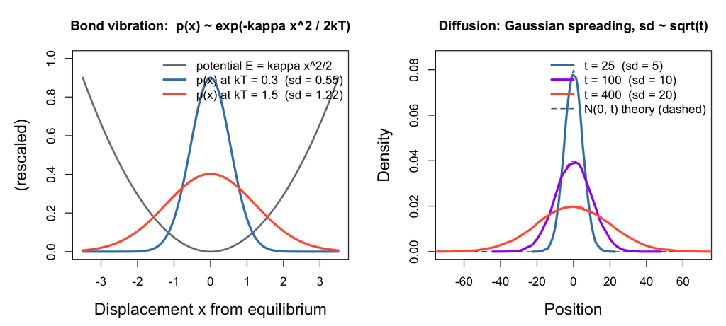

```r
## ── 物理实例：化学键振动 + 布朗扩散 ──────────────────────────

par(mfrow = c(1, 2), mar = c(4.6, 5.0, 3.5, 1))

# 左图：谐振子势 E = kappa x^2 / 2 泡在热浴里 → 位置分布是正态
kappa <- 1
x_b   <- seq(-3.5, 3.5, length.out = 400)
E_pot <- 0.5 * kappa * x_b^2
plot(x_b, E_pot / max(E_pot) * 0.9, type = "l", lwd = 2.5, col = "gray50",
     ylim = c(0, 1.0),
     main = "Bond vibration:  p(x) ~ exp(-kappa x^2 / 2kT)",
     xlab = "Displacement x from equilibrium", ylab = "(rescaled)",
     cex.lab = 1.35, cex.main = 1.1)
kT_b   <- c(0.3, 1.5)
cols_b <- c("steelblue", "tomato")
for (i in seq_along(kT_b)) {
  sd_i <- sqrt(kT_b[i] / kappa)
  lines(x_b, dnorm(x_b, 0, sd_i) / dnorm(0, 0, sqrt(kT_b[1]/kappa)) * 0.9,
        col = cols_b[i], lwd = 3)
}
legend("topright",
       c("potential E = kappa x^2/2",
         paste0("p(x) at kT = ", kT_b, "  (sd = ", round(sqrt(kT_b/kappa), 2), ")")),
       col = c("gray50", cols_b), lwd = c(2.5, 3, 3), bty = "n", cex = 1.0)

# 右图：布朗扩散——随机行走的位置分布是变宽的高斯
n_part  <- 20000
t_snap  <- c(25, 100, 400)
cols_d  <- c("steelblue", "purple", "tomato")
# 每个粒子 = 许多次独立碰撞冲量的累加（每步 ~ N(0,1)）
pos_at <- lapply(t_snap, function(t_i)
  rowSums(matrix(rnorm(n_part * t_i), nrow = n_part)))
plot(NA, xlim = c(-70, 70), ylim = c(0, 0.085),
     main = "Diffusion: Gaussian spreading, sd ~ sqrt(t)",
     xlab = "Position", ylab = "Density",
     cex.lab = 1.35, cex.main = 1.1)
for (i in seq_along(t_snap)) {
  d_i <- density(pos_at[[i]])
  lines(d_i, col = cols_d[i], lwd = 3)
  curve(dnorm(x, 0, sqrt(t_snap[i])), add = TRUE,
        col = cols_d[i], lwd = 1.5, lty = 2)
}
legend("topright",
       c(paste0("t = ", t_snap, "  (sd = ", sqrt(t_snap), ")"),
         "N(0, t) theory (dashed)"),
       col = c(cols_d, "gray40"), lwd = c(3, 3, 3, 1.5),
       lty = c(1, 1, 1, 2), bty = "n", cex = 1.0)
```

# 6 玻尔兹曼分布 = 最大熵 + 能量约束

## 6.1 Boltzmann 原理就是最大熵原理

热力学系统在温度 $T$ 下：

$$\boxed{P(\text{state}) \propto e^{-E /
k_B T}}$$

这个公式常被当作一个”物理定律”来记忆。但它的推导就是最大熵：

- 约束：总能量守恒，$\langle E \rangle$ 固定
- 最大熵解：$p \propto e^{-\lambda E}$

**先说清这一章与前几章的层级关系。** 开篇那张表里，前三行的约束是 $x$ 的具体函数（$x$、$\ln x$、$x^2$），而这一行写的是 $f(x) = E(x)$——**它是个总纲，不是第四个并列的具名分布**。$E(x)$ 一旦落地，掉出来的就是前面已经见过的那几个：

| 能量怎么依赖变量 | $e^{-E/k_BT}$ 成为 | 实例 |
| --- | --- | --- |
| $E$ 对变量**一次**：$E = mgh$、等间距能级 | 该变量的**指数分布** | 等温大气、能级占据 |
| $E$ 对变量**二次**：$E = \frac12 mv_x^2$、$\frac12\kappa x^2$ | 该变量的**高斯分布** | 速度分量、化学键振动 |
| 二次能量 $+$ 非均匀态密度 $g(v)\propto v^2$ | **Maxwell 速率分布** | 分子速率 |

所以”指数、高斯、玻尔兹曼”不是三个互相竞争的分布：**玻尔兹曼因子是共用的机制，指数和高斯是它在一次 / 二次能量下的两张脸**，Maxwell 速率则是再乘上态密度的结果。本章按这个顺序逐个走一遍。

**顺着这一层，得说清一件容易被高估的事：玻尔兹曼形式本身没有排除任何分布。** 给定任意一个处处为正的密度 $p(x)$，只要定义

$$E(x) \;\equiv\; -k_BT\ln
p(x)$$

立刻就有 $p(x)\propto e^{-E(x)/k_BT}$。也就是说，**“这是玻尔兹曼分布”作为一句关于变量 $x$ 的主张，是同义反复**——任何正密度都写得成这个样子。

换句话说，$e^{-E/k_BT}$ 这个**形式**本身不含信息量。玻尔兹曼因子的全部力量，**在于物理独立地告诉你 $E(x)$ 是什么**——重力给 $mgh$、弹簧给 $\frac12\kappa x^2$、动能给 $\frac12 mv^2$。$E$ 是从外部输入的，不是从数据里拟合出来的；一旦 $E$ 被钉死，$e^{-E/k_BT}$ 就变回一个**只剩温度这一个参数**的、可以被证伪的分布。

本章接下来就沿着”$E$ 被物理钉死之后能榨出多少东西”往下走：配分函数如何把温度的一次求导变成能量、二次求导变成涨落；能级的简并如何在玻尔兹曼因子之外再乘一层；以及为什么每个二次自由度恰好分到 $\frac12 k_BT$。

**$\lambda$ 就是拉格朗日乘子。物理学家给它取了个名字：$\beta = 1/(k_BT)$。**

也就是说：**温度不是一个独立的物理量，而是最大熵推导中拉格朗日乘子的倒数。**

- 高温（$\beta$ 小）→ 约束松 → 分布更展开 → 更接近等概
- 低温（$\beta$ 大）→ 约束紧 → 分布集中在低能态
- $T \to \infty$ → $\beta \to 0$ → $p \to \text{Uniform}$（所有态等概）

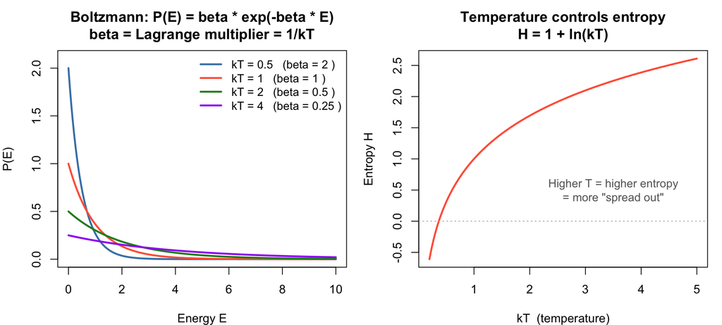

```r
par(mfrow = c(1, 2), mar = c(4, 4, 3.5, 1))

E_seq   <- seq(0, 10, length.out = 400)
kT_vals <- c(0.5, 1, 2, 4)
cols    <- c("steelblue", "tomato", "forestgreen", "purple")

# 左图：不同温度的能量分布
plot(NA, xlim = c(0, 10), ylim = c(0, 2.1),
     main = "Boltzmann: P(E) = beta * exp(-beta * E)\nbeta = Lagrange multiplier = 1/kT",
     xlab = "Energy E", ylab = "P(E)")
for (i in seq_along(kT_vals)) {
  lines(E_seq, dexp(E_seq, rate = 1/kT_vals[i]), col = cols[i], lwd = 2.5)
}
legend("topright", paste("kT =", kT_vals, "  (beta =", 1/kT_vals, ")"),
       col = cols, lwd = 2.5, bty = "n", cex = 0.95)

# 右图：温度 vs 熵
# H[Exp(beta)] = 1 + ln(1/beta) = 1 + ln(kT)
kT_range <- seq(0.2, 5, length.out = 200)
H_boltz  <- 1 + log(kT_range)

plot(kT_range, H_boltz, type = "l", col = "tomato", lwd = 2.5,
     main = "Temperature controls entropy\nH = 1 + ln(kT)",
     xlab = "kT  (temperature)", ylab = "Entropy H")
abline(h = 0, col = "gray70", lty = 3)
text(3.5, 0.5, "Higher T = higher entropy\n= more \"spread out\"",
     col = "gray40", cex = 0.95)
```

## 6.2 温度是什么？$1/T = \partial S / \partial E$

“$\lambda$ 就是 $1/k_BT$”不只是换个记号——它是热力学温度定义和最大熵乘子的严格等同。对最大熵解 $p(E) = \frac{1}{Z}e^{-\lambda E}$ 直接算熵：

$$H = -\int p \ln p = -\int
p\,\bigl(-\lambda E - \ln Z\bigr) = \lambda \langle E\rangle + \ln
Z$$

对 $\langle E\rangle$ 求导（注意 $Z$ 通过 $\lambda$ 依赖 $\langle E\rangle$，用 $\frac{d\ln Z}{d\lambda} = -\langle E\rangle$）：

$$\frac{dH}{d\langle E\rangle} = \lambda +
\underbrace{\left(\langle E\rangle + \frac{d\ln
Z}{d\lambda}\right)}_{=\,0}\frac{d\lambda}{d\langle E\rangle} =
\lambda$$

而热力学里温度的定义（Clausius，$dS = \delta Q / T$）正是 $\dfrac{1}{T} = \dfrac{\partial S}{\partial E}$。两式对照（$S = k_B H$）：

$$\lambda = \frac{1}{k_B T}$$

用本节的指数分布验证：$H = 1 + \ln\langle E\rangle$，$\frac{dH}{d\langle E\rangle} = \frac{1}{\langle E\rangle} = \frac{1}{k_BT}$。✓

**物理直觉**：温度衡量”每注入一单位能量，熵涨多少”——冷系统涨得多（$1/T$ 大），热系统涨得少。两个系统接触时，能量从热流向冷，是因为同一份能量在冷系统那边换到的熵更多，**总熵增大**——热传导的方向也是最大熵推出来的，不需要额外假设。

## 6.3 线性能级 → 指数分布

当能量态密度均匀（如量子谐振子的等间距能级，或二维气体的动能），归一化后：

$$P(E) = \beta\, e^{-\beta E} =
\text{Exponential}(\beta = 1/k_BT)$$

这就是指数分布。**Boltzmann 分布和指数分布不是”类似”——它们是同一个东西。**

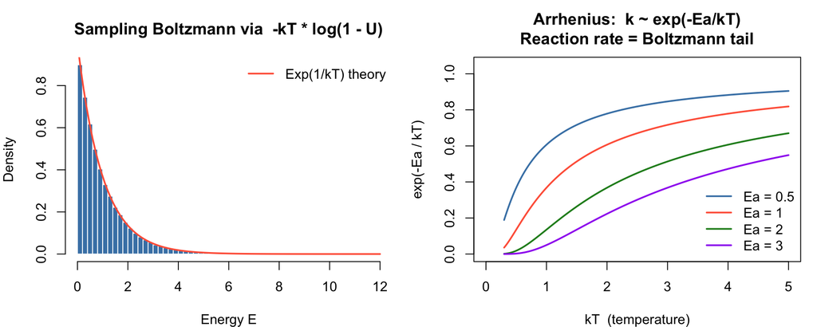

```r
kT <- 1

par(mfrow = c(1, 2), mar = c(4, 4, 3.5, 1))

E_samples <- -kT * log(1 - runif(N))

hist(E_samples, breaks = 80, freq = FALSE, col = "steelblue", border = "white",
     main = "Sampling Boltzmann via  -kT * log(1 - U)",
     xlab = "Energy E")
curve(dexp(x, rate = 1/kT), add = TRUE, col = "tomato", lwd = 2)
legend("topright", "Exp(1/kT) theory", col = "tomato", lwd = 2, bty = "n")

# Arrhenius：反应速率是 Boltzmann 尾巴
Ea_vals <- c(0.5, 1, 2, 3)
kT_range2 <- seq(0.3, 5, length.out = 200)
plot(NA, xlim = c(0, 5), ylim = c(0, 1.05),
     main = "Arrhenius:  k ~ exp(-Ea/kT)\nReaction rate = Boltzmann tail",
     xlab = "kT  (temperature)", ylab = "exp(-Ea / kT)")
arr_cols <- c("steelblue","tomato","forestgreen","purple")
for (i in seq_along(Ea_vals)) {
  lines(kT_range2, exp(-Ea_vals[i] / kT_range2), col = arr_cols[i], lwd = 2)
}
legend("bottomright", paste("Ea =", Ea_vals), col = arr_cols, lwd = 2, bty = "n")
```

化学反应的 Arrhenius 公式 $k = A\, e^{-E_a/(k_BT)}$ 就是 Boltzmann 分布的尾部概率——能越过能垒 $E_a$ 的分子比例。

## 6.4 二次动能 → 正态速度分布

三维气体分子的动能是速度的**二次函数**：$E_x = \frac{1}{2}mv_x^2$

将 Boltzmann 因子作用到动能上：

$$P(v_x) \propto e^{-mv_x^2 / (2k_BT)} =
e^{-v_x^2 / (2\sigma^2)}, \quad \sigma = \sqrt{k_BT/m}$$

这正是正态分布。对比最大熵视角：$f(x) = x^2$，拉格朗日乘子 $\lambda_2 = m/(2k_BT) = 1/(2\sigma^2)$——**物理里的 $m/(2k_BT)$ 就是最大熵推导里的 $\lambda_2$**。

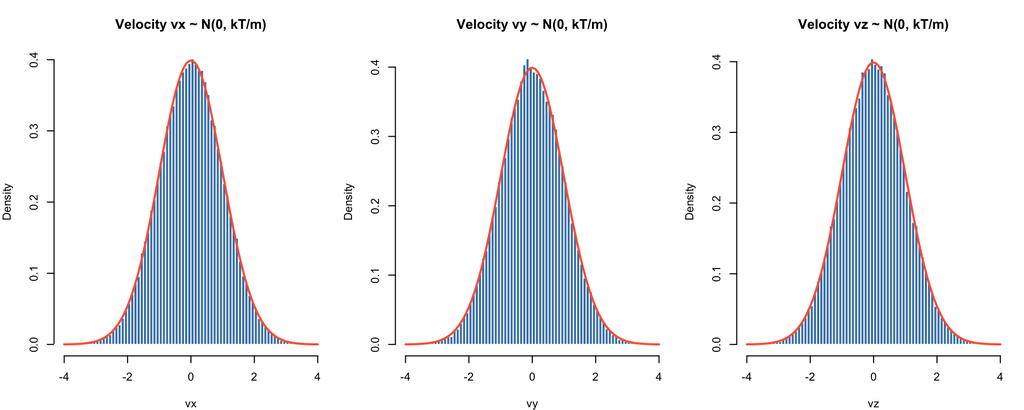

```r
sigma <- 1
vx <- rnorm(N, 0, sigma)
vy <- rnorm(N, 0, sigma)
vz <- rnorm(N, 0, sigma)

par(mfrow = c(1, 3), mar = c(4, 4, 3.5, 1))
for (comp in list(list(v = vx, name = "vx"),
                  list(v = vy, name = "vy"),
                  list(v = vz, name = "vz"))) {
  hist(comp$v, breaks = 80, freq = FALSE, col = "steelblue", border = "white",
       main = paste("Velocity", comp$name, "~ N(0, kT/m)"),
       xlab = comp$name, xlim = c(-4, 4))
  curve(dnorm(x, 0, sigma), add = TRUE, col = "tomato", lwd = 2)
}
```

## 6.5 Maxwell-Boltzmann 速率分布

速率 $v = \sqrt{v_x^2 + v_y^2 + v_z^2}$，由三个独立正态分量合成：

$$f(v) = \sqrt{\frac{2}{\pi}}
\frac{v^2}{\sigma^3} e^{-v^2/(2\sigma^2)}$$

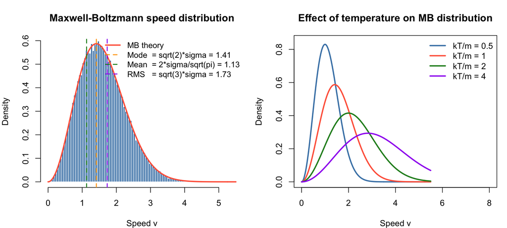

```r
speed  <- sqrt(vx^2 + vy^2 + vz^2)
mb_pdf <- function(v, sigma) sqrt(2/pi) * v^2 / sigma^3 * exp(-v^2 / (2*sigma^2))

v_peak <- sqrt(2) * sigma
v_mean <- 2/sqrt(pi) * sigma
v_rms  <- sqrt(3) * sigma

par(mfrow = c(1, 2), mar = c(4, 4, 3.5, 1))

v_seq <- seq(0, 5.5, length.out = 400)
hist(speed, breaks = 80, freq = FALSE, col = "steelblue", border = "white",
     main = "Maxwell-Boltzmann speed distribution",
     xlab = "Speed v", xlim = c(0, 5.5))
lines(v_seq, mb_pdf(v_seq, sigma), col = "tomato", lwd = 2.5)
abline(v = v_peak, col = "orange",      lty = 2, lwd = 1.8)
abline(v = v_mean, col = "forestgreen", lty = 2, lwd = 1.8)
abline(v = v_rms,  col = "purple",      lty = 2, lwd = 1.8)
legend("topright",
       c("MB theory",
         paste0("Mode  = sqrt(2)*sigma = ", round(v_peak, 2)),
         paste0("Mean  = 2*sigma/sqrt(pi) = ", round(v_mean, 2)),
         paste0("RMS   = sqrt(3)*sigma = ", round(v_rms, 2))),
       col = c("tomato","orange","forestgreen","purple"),
       lwd = c(2.5,1.8,1.8,1.8), lty = c(1,2,2,2), bty = "n", cex = 0.95)

plot(NA, xlim = c(0, 8), ylim = c(0, 0.85),
     main = "Effect of temperature on MB distribution",
     xlab = "Speed v", ylab = "Density")
kTm_vals <- c(0.5, 1, 2, 4)
for (i in seq_along(kTm_vals)) {
  lines(v_seq, mb_pdf(v_seq, sqrt(kTm_vals[i])), col = cols[i], lwd = 2.5)
}
legend("topright", paste("kT/m =", kTm_vals), col = cols, lwd = 2.5, bty = "n")
```

## 6.6 配分函数：不只是归一化常数

前面把 $Z$ 一直当成”把概率凑成 1 的那个分母”。它其实是这一章里最能干的一件工具。

$$Z(\beta) \;=\; \sum_i e^{-\beta E_i}
\qquad\text{（连续情形换成积分）}$$

把 $\ln Z$ 对 $\beta$ 求导，平均能量自己掉出来：

$$-\frac{\partial \ln Z}{\partial \beta}
= \frac{1}{Z}\sum_i E_i\,e^{-\beta E_i}
= \bar E$$

再求一次导，掉出来的是**涨落**：

$$\frac{\partial^2 \ln Z}{\partial
\beta^2} \;=\; \overline{E^2} - \bar E^2 \;=\;
\mathrm{Var}(E)$$

**一个函数 $\ln Z$，求一次导给平均值，求两次导给方差。** 这不是巧合——它是矩母函数那套机器：$\ln Z(\beta)$ 就是能量的**累积量母函数**。

拿最小的系统试一遍：**两能级系统**（能量 $0$ 与 $\Delta$，比如一个只能”基态/激发态”二选一的分子）。$Z = 1 + e^{-\beta\Delta}$，于是

$$p_1 =
\frac{e^{-\beta\Delta}}{1+e^{-\beta\Delta}}, \qquad \bar E =
\Delta\,p_1$$

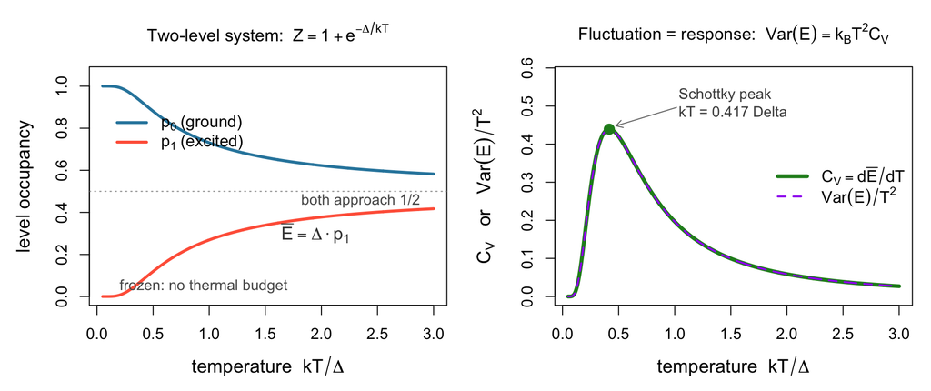

```r
D <- 1                                    # 能隙 Δ，取 k_B = 1
Zf <- function(b) 1 + exp(-b*D)
p1 <- function(Tt) exp(-D/Tt)/Zf(1/Tt)
Em <- function(Tt) D*exp(-D/Tt)/Zf(1/Tt)
Va <- function(Tt) D^2*exp(-D/Tt)/Zf(1/Tt)^2
Ts <- seq(0.05, 3, length.out = 1200)
h  <- 1e-6
CV <- sapply(Ts, function(t) (Em(t+h) - Em(t-h))/(2*h))     # C_V = d<E>/dT，数值导数

par(mfrow = c(1, 2), mar = c(4.6, 4.8, 3.6, 1))

## 左：两个能级的占据数
plot(Ts, 1 - p1(Ts), type = "l", lwd = 3, col = "#2E86AB", ylim = c(0, 1.05),
     main = expression("Two-level system:  "*Z == 1 + e^{-Delta/kT}),
     xlab = expression("temperature  "*kT/Delta), ylab = "level occupancy",
     cex.lab = 1.2, cex.main = 1.1)
lines(Ts, p1(Ts), lwd = 3, col = "tomato")
abline(h = 0.5, col = "gray60", lty = 3)
text(2.35, 0.455, "both approach 1/2", col = "gray35", cex = 0.95)
text(0.95, 0.05, "frozen: no thermal budget", col = "gray35", cex = 0.95)
text(1.95, 0.30, expression(bar(E) == Delta%.%p[1]), col = "gray25", cex = 1.15)
legend(0.05, 0.92, legend = expression(p[0]~"(ground)", p[1]~"(excited)"),
       col = c("#2E86AB", "tomato"), lwd = 3, bty = "n", cex = 1.05)

## 右：涨落 = 响应
plot(Ts, CV, type = "l", lwd = 4, col = "forestgreen", ylim = c(0, max(CV)*1.32),
     main = expression("Fluctuation = response:  "*Var(E) == k[B]*T^2*C[V]),
     xlab = expression("temperature  "*kT/Delta), ylab = expression(C[V]*"   or   "*Var(E)/T^2),
     cex.lab = 1.2, cex.main = 1.1)
lines(Ts, Va(Ts)/Ts^2, lwd = 2, col = "purple", lty = 2)
pk <- Ts[which.max(CV)]
points(pk, max(CV), pch = 16, col = "forestgreen", cex = 1.6)
arrows(pk + 0.60, max(CV)*1.13, pk + 0.06, max(CV)*1.02, length = 0.08, col = "gray45")
text(pk + 0.62, max(CV)*1.16, sprintf("Schottky peak\nkT = %.3f Delta", pk),
     col = "gray30", cex = 0.95, adj = 0)
legend("right", legend = expression(C[V] == d*bar(E)/dT, Var(E)/T^2),
       col = c("forestgreen", "purple"), lwd = c(4, 2), lty = c(1, 2), bty = "n", cex = 1.05)
```

左图：低温时系统冻在基态（$p_1\to0$，没有热预算去爬那个能隙），高温时两个能级**平分**（$p_1\to1/2$，$k_BT$ 远大于 $\Delta$，能隙形同不存在）。注意高温极限不是”全跑到高能级”，而是**等概率**——这正是 $T\to\infty$ 时玻尔兹曼因子趋于均匀。

右图是这一节的重点。热容 $C_V = \mathrm{d}\bar E/\mathrm{d}T$ 是**你能测的宏观响应**：升一度要灌多少能量。而 $\mathrm{Var}(E)$ 是**微观涨落**。两条曲线严丝合缝地压在一起，因为

$$\boxed{\;\mathrm{Var}(E) \;=\; k_B T^2\,
C_V\;}$$

——涨落和响应是同一个二阶导的两种读法（$\partial^2\ln Z/\partial\beta^2$）。**系统越”容易被加热”，它的能量本来就抖得越厉害。** 峰出现在 $k_BT \approx 0.417\,\Delta$（Schottky 峰）：温度太低爬不上去、太高已经饱和，只有在能隙尺度附近，加一点热量才最能改变占据数。

这台”$\ln Z$ 求导出矩”的机器不是热力学专属。记住它的三个零件——**指数里的 $\beta$、被平均的 $E$、归一化的 $\ln Z$**——末章会看到它们在统计学里各有名字（自然参数、充分统计量、累积量母函数），而玻尔兹曼分布只是这套结构最早被物理学发现的那个特例。

## 6.7 简并与态密度：玻尔兹曼因子只是一半

到这里有个容易被忽略的缺口。玻尔兹曼因子说的是”**每一个状态**的概率 $\propto e^{-\beta E}$“。但如果你关心的不是状态而是**能量**，就还得数清楚：**同一个能量上有多少个状态**。

$$p(E) \;\propto\;
\underbrace{g(E)}_{\text{有多少个格子}}\;\cdot\;\underbrace{e^{-E/k_BT}}_{\text{每个格子多重}}$$

$g(E)$ 是简并度（离散能级）或态密度（连续能量）。两个因子的方向正好相反——格子数往上、权重往下——于是概率的峰不在能量最低处：

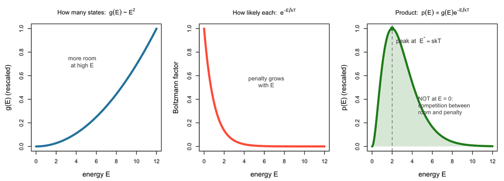

```r
Tt <- 1; b <- 1/Tt; s <- 2                     # g(E) ∝ E^s，取 k_B = 1
E  <- seq(0, 12, length.out = 1500)
g  <- E^s; bz <- exp(-b*E); pr <- g*bz
par(mfrow = c(1, 3), mar = c(4.5, 4.7, 3.6, 1))

plot(E, g/max(g), type = "l", lwd = 4, col = "#2E86AB",
     main = expression("How many states:  "*g(E)*" ~ "*E^2),
     xlab = "energy E", ylab = "g(E) (rescaled)", cex.lab = 1.25, cex.main = 1.1)
text(4.6, 0.72, "more room\nat high E", col = "gray30", cex = 1.05)

plot(E, bz, type = "l", lwd = 4, col = "tomato",
     main = expression("How likely each:  "*e^{-E/kT}),
     xlab = "energy E", ylab = "Boltzmann factor", cex.lab = 1.25, cex.main = 1.1)
text(6.2, 0.55, "penalty grows\nwith E", col = "gray30", cex = 1.05)

plot(E, pr/max(pr), type = "l", lwd = 4, col = "forestgreen",
     main = expression("Product:  "*p(E) %prop% g(E)*e^{-E/kT}),
     xlab = "energy E", ylab = "p(E) (rescaled)", cex.lab = 1.25, cex.main = 1.1)
polygon(c(E, rev(E)), c(pr/max(pr), rep(0, length(E))),
        col = adjustcolor("forestgreen", 0.18), border = NA)
abline(v = s*Tt, col = "gray40", lty = 2)
points(s*Tt, 1, pch = 16, col = "forestgreen", cex = 1.7)
text(s*Tt + 0.4, 0.90, expression("peak at  "*E^"*" == s*kT), col = "gray25", cex = 1.1, adj = 0)
text(4.6, 0.35, "NOT at E = 0:\ncompetition between\nroom and penalty",
     col = "gray30", cex = 1.02, adj = 0)
```

把 $g(E)\propto E^s$ 代进去求极值，峰的位置有闭式：

$$\frac{\mathrm{d}}{\mathrm{d}E}\Bigl[s\ln
E - \beta E\Bigr] = 0
\;\Longrightarrow\; E^\ast = \frac{s}{\beta} = s\,k_BT$$

图里 $s=2$、$k_BT=1$，峰精确落在 $E^\ast=2$。所以”最可能的能量”随温度线性上移，而且**恒不为零**——尽管每一个具体状态都是越低越可能。这就是本章前面 Maxwell **速率**分布那个 $v^2$ 因子的来处：三维速度空间里半径为 $v$ 的球壳面积 $\propto v^2$，就是 $g(v)$。速度**分量**是纯高斯（$g$ 均匀），速率却有个先升后降的峰。

这里请记住这个 $g$ 的位置：它**不来自约束、也不来自玻尔兹曼因子**，而是”你拿什么当计数单位”。末章会给它一个统计学的名字（基测度），并说明它其实一直潜伏在前面每一个推导里。

## 6.8 等分定理：每个二次自由度分到 $\frac12 k_BT$

第5章说过：能量对坐标二次，分布就是高斯。反过来问一句——**那这个自由度平均拿到多少能量?**

一维弹簧势 $E = \frac12\kappa x^2$，位置服从 $\sigma^2 = k_BT/\kappa$ 的高斯，于是

$$\bar E = \tfrac12\kappa\,\overline{x^2}
= \tfrac12\kappa\sigma^2 = \tfrac12 k_BT$$

**$\kappa$ 消掉了。** 弹簧软还是硬、分子轻还是重，都不影响这个自由度分到的能量——只由温度决定。

```r
kap <- 2.7                                  # 任取一个刚度，k_B = 1
chk <- sapply(c(0.5, 1, 3), function(Tt){
  x <- rnorm(2e6, 0, sqrt(Tt/kap))          # p(x) ∝ exp(-kappa x^2 / 2T)
  c(T = Tt, simulated = mean(0.5*kap*x^2), theory = 0.5*Tt)
})
round(t(chk), 5)
```

```
##        T simulated theory
## [1,] 0.5   0.24974   0.25
## [2,] 1.0   0.50003   0.50
## [3,] 3.0   1.49939   1.50
```

推广就是**等分定理**：能量里每一个二次项（每个方向的动能、每个简谐坐标）平均分到 $\frac12 k_BT$；$f$ 个二次自由度给出 $\bar E = \frac f2 k_BT$、$C_V = \frac f2 k_B$。单原子气体三个平动方向 → $\frac32 k_BT$，这就是理想气体那个熟悉的结果。

顺带解释了一件事：**为什么温度可以用”每个自由度的能量”来定义**。$k_BT$ 不是随便一个换算因子，它就是热浴发给每个二次自由度的那份”零花钱”。

## 6.9 自由能：最大熵的另一面

最后补一个抽象台阶——它是本章通向末章的桥。

把 $\bar E = -\partial_\beta\ln Z$ 和熵合起来算（$S = k_B H$，$H = -\sum p\ln p$，代入 $p_i = e^{-\beta E_i}/Z$）：

$$S = k_B\bigl(\beta\bar E + \ln Z\bigr)
\qquad\Longrightarrow\qquad
\boxed{\;-k_BT\ln Z \;=\; \bar E - TS \;\equiv\; F\;}$$

$F$ 就是**自由能**。于是同一件事有了两种说法：

- **最大熵视角**：固定平均能量 $\bar E$，最大化熵 $S$；
- **自由能视角**：固定温度 $T$，最小化 $F = \bar E - TS$。

两者是一对 **Legendre 变换**（$\bar E$ 与 $\beta$ 互为共轭变量，正如价格与数量）。这解释了物理里那句常见的话”系统趋于最小自由能”——它不是与最大熵原理并列的另一条定律，而是**同一条定律在”温度给定”而非”能量给定”时的写法**。

末章会看到 $\ln Z$ 在统计学里的名字，以及这个 Legendre 对偶如何变成指数族的凸共轭——同一套结构，两个学科各自命名了一遍。

# 7 统一图景：指数族与 $p \propto e^{-\lambda f(x)}$

## 7.1 一个方程，四种分布

回到最大熵的通解 $p \propto e^{-\lambda f(x)}$：

$$p(x) \propto e^{-\lambda_1 f_1(x) -
\lambda_2 f_2(x) - \cdots}$$

这在统计学中称为**指数族**（exponential family）。自然界反复出现这些分布，不是因为它们”好看”，而是因为它们是**在有限信息下最不偏不倚的选择**。

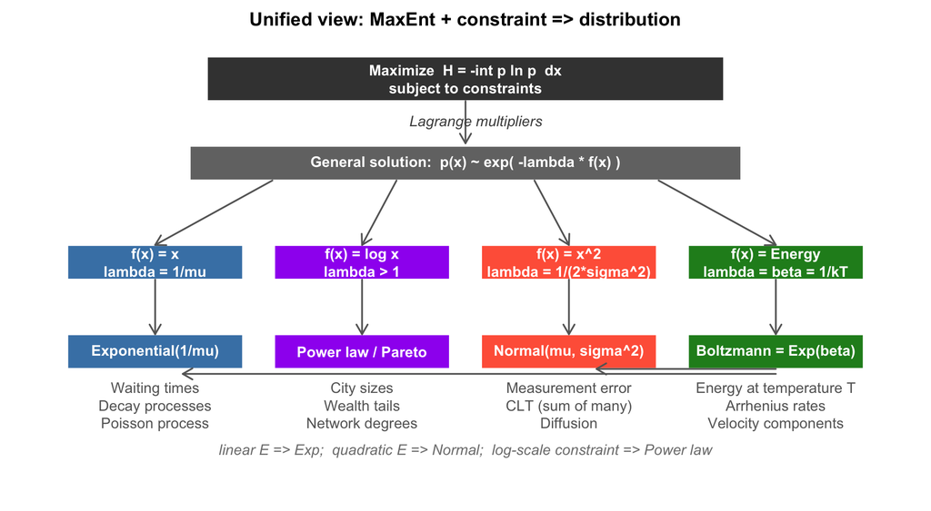

```r
par(mar = c(1, 1, 2, 1))
plot(NA, xlim = c(0, 12), ylim = c(0, 8.5), axes = FALSE, bty = "n",
     xlab = "", ylab = "",
     main = "Unified view: MaxEnt + constraint => distribution")

draw_box <- function(x, y, label, col, w = 3.5, h = 0.7, cex = 0.95) {
  rect(x-w/2, y-h/2, x+w/2, y+h/2, col = col, border = "white", lwd = 2)
  text(x, y, label, col = "white", font = 2, cex = cex)
}
draw_arr <- function(x0, y0, x1, y1, label = "") {
  arrows(x0, y0, x1, y1, length = 0.12, lwd = 1.8, col = "gray40")
  mx <- (x0+x1)/2; my <- (y0+y1)/2
  if (nchar(label) > 0) text(mx + 0.15, my, label, cex = 0.95, col = "gray30", font = 3)
}

# Top: MaxEnt principle
draw_box(6, 8, "Maximize  H = -int p ln p  dx\nsubject to constraints",
         "gray25", w = 7.5, h = 0.9)

# General solution
draw_box(6, 6.3, "General solution:  p(x) ~ exp( -lambda * f(x) )",
         "gray45", w = 8, h = 0.7)

draw_arr(6, 7.55, 6, 6.7, "Lagrange multipliers")

# Four branches
draw_box(1.5, 4.3, "f(x) = x\nlambda = 1/mu",              "steelblue",  w = 2.55, cex = 0.95)
draw_box(4.5, 4.3, "f(x) = log x\nlambda > 1",             "purple",     w = 2.55, cex = 0.95)
draw_box(7.5, 4.3, "f(x) = x^2\nlambda = 1/(2*sigma^2)",    "tomato",     w = 2.55, cex = 0.95)
draw_box(10.5, 4.3, "f(x) = Energy\nlambda = beta = 1/kT",  "forestgreen", w = 2.55, cex = 0.95)

draw_arr(3.2, 5.95, 1.5,  4.65)
draw_arr(5.0, 5.95, 4.5,  4.65)
draw_arr(7.0, 5.95, 7.5,  4.65)
draw_arr(8.8, 5.95, 10.5, 4.65)

# Results
draw_box(1.5,  2.5, "Exponential(1/mu)",     "steelblue",  w = 2.55, cex = 0.95)
draw_box(4.5,  2.5, "Power law / Pareto",    "purple",     w = 2.55, cex = 0.95)
draw_box(7.5,  2.5, "Normal(mu, sigma^2)",   "tomato",     w = 2.55, cex = 0.95)
draw_box(10.5, 2.5, "Boltzmann = Exp(beta)", "forestgreen", w = 2.55, cex = 0.95)

draw_arr(1.5,  3.95, 1.5,  2.85)
draw_arr(4.5,  3.95, 4.5,  2.85)
draw_arr(7.5,  3.95, 7.5,  2.85)
draw_arr(10.5, 3.95, 10.5, 2.85)

# Physical examples
text(1.5,  1.42, "Waiting times\nDecay processes\nPoisson process",
     cex = 0.95, col = "gray40")
text(4.5,  1.42, "City sizes\nWealth tails\nNetwork degrees",
     cex = 0.95, col = "gray40")
text(7.5,  1.42, "Measurement error\nCLT (sum of many)\nDiffusion",
     cex = 0.95, col = "gray40")
text(10.5, 1.42, "Energy at temperature T\nArrhenius rates\nVelocity components",
     cex = 0.95, col = "gray40")

# Connection between Boltzmann → Exp and Normal
draw_arr(10.5, 2.15, 7.9, 2.15)
draw_arr(10.5, 2.05, 1.9, 2.05)
text(6.0, 0.5, "linear E => Exp;  quadratic E => Normal;  log-scale constraint => Power law",
     cex = 0.95, col = "gray50", font = 3)
```

## 7.2 先说清那把尺子：测度是什么

下一节要用到”参照测度”。这个词听着像泛函分析的门槛，其实东西朴素得多，而且不讲清它，下一节的主角就会变成一句咒语。先花一节把它说透。

**测度就是”你怎么数有多少”。** 给你一段区间 $[a,b]$，问它”有多大”，最自然的回答是长度 $b-a$。把这种”给集合指定大小”的规则严格化的人是 Henri Lebesgue（1902），所以”按普通长度来数”这把尺子就叫 **Lebesgue 测度**，在积分里就是那个不起眼的 $\mathrm{d}x$。

关键在于：**尺子不止一把。** 你可以按长度数，也可以按”数量级”数（每十倍算一格），也可以在整数上一个点算一格。换一把尺子，“均匀”“分散”“无知”这些词的含义就跟着变。

### 7.2.1 为什么熵必须先说清尺子

离散熵不用操心这件事：它数的是状态，无量纲，换什么单位都一样。**连续情形不然**——微分熵**不是坐标无关的**。看一个例子：

```r
Hnum <- function(dens, lo, hi)                     # 数值积分算微分熵
  -integrate(function(x){p <- dens(x); ifelse(p > 0, p*log(p), 0)}, lo, hi)$value

# 同一根"0 到 1 米之间均匀随机"的长度，只是换记录单位
c(以米计   = Hnum(function(x) dunif(x, 0, 1),    0, 1),
  以厘米计 = Hnum(function(x) dunif(x, 0, 100),  0, 100),
  以毫米计 = Hnum(function(x) dunif(x, 0, 1000), 0, 1000),
  ln100    = log(100), ln1000 = log(1000)) |> round(4)
```

```
##   以米计 以厘米计 以毫米计    ln100   ln1000
##   0.0000   4.6052   6.9078   4.6052   6.9078
```

**同一件随机事实，换个单位，熵的数值就变了**——以米计是 $0$，以厘米计变成 $\ln 100 = 4.605$。原因不神秘：概率密度 $p$ 是带单位的（每米多少概率），换单位时 $p$ 整体缩放，$\ln p$ 就整体平移。

所以”微分熵的绝对数值”本身没有意义，它只在**给定一把尺子之后**才有意义。这也顺带解释了前面见过的那件怪事：指数分布 $\mu < 1/e$ 时 $H<0$——负号不代表”信息量为负”，只代表这个分布比”单位长度那么宽”更集中。**微分熵测的是”相对于尺子有多分散”。**

### 7.2.2 相对熵才是不依赖尺子的那个量

既然如此，正确的做法是把尺子写进公式。**相对熵**（KL 散度）就是这么干的：

$$D(p\,\|\,m) \;=\; \int
p(x)\,\ln\frac{p(x)}{m(x)}\,\mathrm{d}x$$

$m$ 就是那把尺子（参照测度）。换单位时 $p$ 和 $m$ **同步**缩放，比值 $p/m$ 不变，于是 $D$ 也不变：

```r
# p = Beta(2,5)；参照 m = 该区间上的均匀分布。再换成厘米看一遍
D_m  <- integrate(function(x) dbeta(x,2,5)*log(dbeta(x,2,5)/dunif(x,0,1)), 0, 1)$value
D_cm <- integrate(function(y) (dbeta(y/100,2,5)/100) *
                              log((dbeta(y/100,2,5)/100)/(1/100)), 0, 100)$value
c(相对熵_米 = D_m, 相对熵_厘米 = D_cm,
  微分熵_米 = Hnum(function(x) dbeta(x,2,5), 0, 1),
  微分熵_厘米 = Hnum(function(y) dbeta(y/100,2,5)/100, 0, 100)) |> round(5)
```

```
##   相对熵_米 相对熵_厘米   微分熵_米 微分熵_厘米
##     0.48453     0.48453    -0.48453     4.12064
```

相对熵两次完全相同，微分熵却差了 $\ln 100$。**所以严格地说，该最大化的从来是相对熵；本文前面一路写的”最大化 $H$“，是”参照测度取成常数（Lebesgue）“时的简写。** 这句话就是下一节整个推广的全部内容。

### 7.2.3 术语对表（同一个东西的几个名字）

这里有个纯粹的命名混乱，值得单独澄清一下：

| 说法 | 指什么 |
| --- | --- |
| **参照测度 / 背景测度 / 基测度 / base measure** | **都是同一个东西**：公式里那个 $m$，你选的那把尺子 |
| **Lebesgue 测度** | 尺子的一个**具体选择**：按普通长度数（$m=$ 常数，积分里的 $\mathrm{d}x$） |
| **计数测度** | 另一个具体选择：离散点上，一个点算一格（$m(y)=1$） |
| 态密度 $g(E)$ / 简并度 | 物理学对同一件事的叫法（第 6 章那个 $g$） |

也就是说：**“参照测度”是角色，“Lebesgue 测度”是演员之一。**

### 7.2.4 三把常用的尺子

| 尺子 | 数法 | “什么都不知道”时给出 |
| --- | --- | --- |
| **等长尺**（Lebesgue，$\mathrm{d}x$） | 每段等长同等重要，普通直尺 | 有界区间上的**均匀分布** |
| **计数尺**（$m(y)=1$） | 整数上一个点算一格 | 整数上的均匀；配固定均值给**几何分布** |
| **对数尺**（$\mathrm{d}x/x$） | **每个数量级等宽**，像地震震级、pH、分贝 | $p\propto 1/x$，一条**幂律** |

第三把最值得试一下手感。$\mathrm{d}x/x$ 是”对数刻度上的等长”（因为 $\mathrm{d}\ln x = \mathrm{d}x/x$）。在这把尺子上均匀，意思是**每个数量级的概率相同**：

```r
Z <- log(1000)                                # 支撑取 [1, 1000]，p(x) = 1/(x*Z)
sapply(1:3, function(d)
  integrate(function(x) 1/(x*Z), 10^(d-1), 10^d)$value) |>
  setNames(c("1~10", "10~100", "100~1000")) |> round(4)
```

```
##     1~10   10~100 100~1000
##   0.3333   0.3333   0.3333
```

三个数量级各占 $1/3$——落在 1 到 10 之间和落在 100 到 1000 之间一样可能。这正是”**对数尺度上什么都不知道**”的样子，而它在普通直尺上看就是幂律 $1/x$。为什么这把尺子配幂律天然合适？因为 $\mathrm{d}x/x$ 是**唯一**在 $x\to cx$（整体放大）下不变的尺子——量纲上”倍数”才是它的单位，而幂律正是没有特征尺度的那个分布。

准备工作到此为止。下一节把 $m$ 正式请进公式，看它如何一口气点亮整个分布动物园。

## 7.3 完整的指数族：一个模板，点亮整个动物园

前面每个分布都写成 $p\propto e^{-\lambda f(x)}$。但这还不是最全的形式——它悄悄假设了一样东西。补上它，就得到统计学里统一万物的那个对象：**指数族**。

**被隐藏的参照测度。** 写 $H=-\int p\ln p\,dx$ 时，其实默认了一个参照：$m(x)=$ 常数（Lebesgue 测度，“每段等长的 $dx$ 同等重要”）。更一般地，该最大化的是**相对熵** $-\int p\ln\frac{p}{m}\,dx$；对 $p$ 逐点求变分（$\frac{\delta}{\delta p}\bigl[-p\ln\frac{p}{m}\bigr] = -\ln\frac{p}{m}-1$，令它加上乘子项为零）解出

$$\boxed{\,p(x)\;\propto\;m(x)\,e^{-\sum_i
\lambda_i f_i(x)}\,}$$

这就是**指数族**的一般形式。两个零件生成整个分布动物园：**参照测度 $m$**（你在什么”背景几何”上计数）＋ **约束函数 $\{f_i\}$**（你知道哪些量）。前面各章都是它取 $m=$ 常数、$f$ 取 $x$／$x^2$／$\ln x$／$E$ 的特例。

**换一个背景测度，就换出一整族分布。**

*离散计数* $y=0,1,2,\dots$：最朴素的情形——非负整数 + 固定均值，普通最大熵给的**不是 Poisson，而是 Geometric** $p_y=(1-\theta)\theta^y$（指数分布在整数格点上的孪生）。要得到 Poisson，必须把参照测度换成 $m(y)=1/y!$；Binomial 要 $m(y)=\binom{n}{y}$。这些组合数是”计数的背景结构”，约束变不出来，只能由 $m$ 提供：

| 分布 | 基测度 $m(y)$ | 约束 | 结果 |
| --- | --- | --- | --- |
| Geometric | $1$ | $E[Y]=\mu$ | $(1-\theta)\theta^y$ |
| Poisson | $1/y!$ | $E[Y]=\mu$ | $e^{-\mu}\mu^y/y!$ |
| Binomial | $\binom{n}{y}$ | $E[Y]=np$ | $\binom{n}{y}p^y(1-p)^{n-y}$ |

*尺度不变测度* $dx/x$（对 $\ln x$ 均匀，因为 $d\ln x=dx/x$）：什么约束都不加，解就是 $p\propto 1/x$——幂律。所以幂律是”**对数尺度上什么都不知道**”的分布，正如均匀是”线性尺度上什么都不知道”。base measure 不是补丁，而是最大熵一直在用的**隐藏坐标系**：换掉它，“最无知”长什么样就跟着变。

**格局。** $m(x)\,e^{-\sum\lambda_i f_i}$ 不是本文的小把戏，它是现代统计的核心对象——**指数族**：$\{f_i\}$ 是充分统计量，$\lambda_i$ 是自然参数；广义线性模型（GLM）、共轭先验、最大似然的一整套漂亮性质都建在这个形式上。回头看，本文一路点亮的指数、幂律、正态、玻尔兹曼、几何、泊松……不过是**同一个母体——指数族——的不同角落**。

## 7.4 为什么自然界总是这些分布？

不是因为自然”选择”了这些函数形式，而是因为：

> **在约束条件下，微观实现方式最多的宏观状态就是最大熵状态。**

自然界不追求最低能量，也不追求最高能量，而是追求**最容易实现的状态**——即微观排列数最多的分布。指数型衰减 $e^{-\lambda f(x)}$ 之所以反复出现，是因为它是约束优化问题的通解。

# 8 全文总结

一条主线贯穿全篇：**优化一个量 + 施加若干约束 → 唯一确定的结构**。

1. **优化什么**：熵 $H = -\int p\ln p\,dx$。它不是任意选的——计数论证证明了 $\ln W \approx N\cdot H$，熵最大的分布就是微观排列数压倒性最多、因而几乎必然出现的那个（$W \approx e^{NH}$）。
2. **怎么优化**：拉格朗日乘子 / 变分法。约束吃进拉格朗日函数，对分布逐点求导，通解一步落地：$p(x) \propto e^{-\lambda f(x)}$。
3. **约束是什么**：由你的已知信息（测量或守恒律）决定。换一个约束函数 $f(x)$，就换一个分布：

| 约束 $f(x)$ | 得到的分布 | 乘子的物理身份 | 实例 |
| --- | --- | --- | --- |
| 无（仅有界） | 均匀分布 | — | — |
| $x$（均值，非负） | 指数分布 | — | 等温大气、放射性衰变 |
| $\ln x$（几何均值，$x\ge x_{\min}$） | 幂律分布 / Pareto | — | 城市规模、财富尾部、网络度数 |
| $x,\ x^2$（均值+方差） | 正态分布 | — | 化学键振动、布朗扩散 |
| $E(x)$（能量） | 玻尔兹曼分布 | $\lambda = 1/k_BT$（温度） | Maxwell 速率、Arrhenius |

指数、幂律、正态、玻尔兹曼——这四个看似无关的分布，因此是同一个方程在不同约束下的四张脸（均匀分布则是”无约束”的基线）。而这套”优化 + 约束”的模板远不止于此：拉格朗日乘子在力学里是约束力、在热力学里是温度/化学势/压强、在优化里是对偶变量——它是连接**数学、物理、化学**的一根共同轴。

> 一句话带走：**指数族不是自然界的审美偏好，而是”给定参照测度、只知道有限几个平均量”这一推断处境的数学结论。**

这句话的分量要放准：它的必然性**属于推断，不属于自然**。三个前提（参照测度固定、约束有限且已知、最大化熵）任一松动，结论就不成立——自然界里确有不属于指数族的分布：Student-$t$、Cauchy、Lévy 稳定律、混合分布、以及支撑随参数变动的族（未知 $x_{\min}$ 的 Pareto、未知形状的 Weibull）。反过来也一样要紧：**是指数族的分布，也常常不是靠”诚实推断”产生的**——正态可以由中心极限定理（加法聚合）长出来，幂律可以由优先增长、Kesten 过程或临界分枝长出来，这些机制与”在有限信息下最诚实”没有关系。

所以同一个分布往往有两套互不隶属的来路：**最大熵回答”在这点信息下我该假设什么”，机制回答”它实际会长成什么”。** 两条路频繁重合（正态、指数、幂律都各有两套解释），但它们回答的不是同一个问题——重合本身才是这件事最耐琢磨的地方。

*作者：胡杨博士 ｜ 首次发布：2026-07-12 ｜ 最后更新：2026-08-26 16:24 EDT*

# 参考文献

Beggs, John M., and Dietmar Plenz. 2003. “Neuronal Avalanches in Neocortical Circuits.” *The Journal of Neuroscience* 23 (35): 11167–77. https://doi.org/10.1523/JNEUROSCI.23-35-11167.2003.

Boltzmann, Ludwig. 1877. “Ueber Die Beziehung Zwischen Dem Zweiten Hauptsatze Der Mechanischen w"armetheorie Und Der Wahrscheinlichkeitsrechnung Respektive Den s"atzen "uber Das w"armegleichgewicht.” *Sitzungsberichte Der Kaiserlichen Akademie Der Wissenschaften. Mathematisch-Naturwissenschaftliche Classe* 76: 373–435. https://doi.org/10.3390/e17041971.

Broido, Anna D., and Aaron Clauset. 2019. “Scale-Free Networks Are Rare.” *Nature Communications* 10: 1017. https://doi.org/10.1038/s41467-019-08746-5.

Cercignani, Carlo. 2006. *Ludwig Boltzmann: The Man Who Trusted Atoms*. Oxford University Press.

Clauset, Aaron, Cosma Rohilla Shalizi, and Mark E. J. Newman. 2009. “Power-Law Distributions in Empirical Data.” *SIAM Review* 51 (4): 661–703. https://doi.org/10.1137/070710111.

Gabaix, Xavier. 2009. “Power Laws in Economics and Finance.” *Annual Review of Economics* 1: 255–94. https://doi.org/10.1146/annurev.economics.050708.142940.

Harris, Theodore E. 1963. *The Theory of Branching Processes*. Vol. 119. Grundlehren Der Mathematischen Wissenschaften. Springer. https://doi.org/10.1007/978-3-642-51850-3.

Jaynes, Edwin T. 1957. “Information Theory and Statistical Mechanics.” *Physical Review* 106 (4): 620–30. https://doi.org/10.1103/PhysRev.106.620.

Kesten, Harry. 1973. “Random Difference Equations and Renewal Theory for Products of Random Matrices.” *Acta Mathematica* 131: 207–48. https://doi.org/10.1007/BF02392040.

Moivre, Abraham de. 1733. *Approximatio Ad Summam Terminorum Binomii (a+b)^n in Seriem Expansi*. https://doi.org/10.5281/zenodo.18913559.

Planck, Max. 1901. “Ueber Irreversible Strahlungsvorg"ange.” *Annalen Der Physik* 311 (12): 818–31. https://doi.org/10.1002/andp.19013111210.

Shannon, Claude E. 1948. “A Mathematical Theory of Communication.” *Bell System Technical Journal* 27 (3–4): 379–423, 623–56. https://doi.org/10.1002/j.1538-7305.1948.tb01338.x.

Stirling, James. 1730. *Methodus Differentialis: Sive Tractatus de Summatione Et Interpolatione Serierum Infinitarum*. G. Strahan. https://books.google.com/books?id=71ZHAAAAYAAJ.

Tribus, Myron, and Edward C. McIrvine. 1971. “Energy and Information.” *Scientific American* 225 (3): 179–88. https://doi.org/10.1038/scientificamerican0971-179.

West, Geoffrey B., James H. Brown, and Brian J. Enquist. 1997. “A General Model for the Origin of Allometric Scaling Laws in Biology.” *Science* 276 (5309): 122–26. https://doi.org/10.1126/science.276.5309.122.

## 留言与讨论

读到不清楚、觉得有错、或想到别的例子，都欢迎在下面留言（用 GitHub 账号登录即可）。 留言支持 Markdown、代码块和 `$LaTeX$` 公式。